# Regresyon Analizi Final Ödevi

Muhammet Fatih ANAÇ 121521057

2024-01-17

## Gerekli Paketler

```r
library(mice)
library(broom)
library(InformationValue)
library(pscl)
library(pROC)
library (glmnet)
library(tidyverse)
library(caret)
library(car)
library(dplyr)
library(lmtest)
```

## Verinin Tanıtılması

Verisetim; bir telekom firmasının müşterilerine ait bilgilerden oluşuyor. Bu bilgilerin, müşterinin telekom firmasını kullanmaya devam edip etmeyeceği sonucunu ne kadar açıklayabileceğini görmek için lojistic regresyon uygulaması yapacağım. Tahmin etmeye çalıştığım değişken yani bağımlı değişkenim: Churn, bu değişkenin sonucunu etkilediğini düşündüğüm ve bu değişkenin sonucunu tahmin ederken kullancağım bağımsız değişkenlerim: tenure= kullanım süresi, PhoneService= Telefon servisi, Contract= Sözleşme, PaperlessBilling= Kağıtsız faturalandırma, PaymentMethod= Ödeme Yöntemi, MonthlyCharges= Yapılan Aylık Yükleme, TotalCharges= Toplam Yükleme.

Churn değişkenimin değerleri 0 ve 1’lerden oluşuyor. 0 değeri, müşterinin telekom firmasını kullanmaya devam edeceğini; 1 değeri ise müşterinin telekom firmasını kullanmaya devam etmeyeceğini gösteriyor.

```r
veriseti<-read.csv("C:/Users/m.fatih/OneDrive/Masaüstü/Regresyon Analizi Final Ödevi/churn_data.csv")
View(veriseti)
veriseti$customerID<-NULL
View(veriseti)
table(veriseti$Churn)
```

```
##
##   No  Yes
## 5173 1869
```

```r
names(veriseti)
```

```
## [1] "tenure"           "PhoneService"     "Contract"         "PaperlessBilling"
## [5] "PaymentMethod"    "MonthlyCharges"   "TotalCharges"     "Churn"
```

## Eksik Gözlemler

Öncelikle verisetimde eksik gözlem var mı bakmak istiyorum.

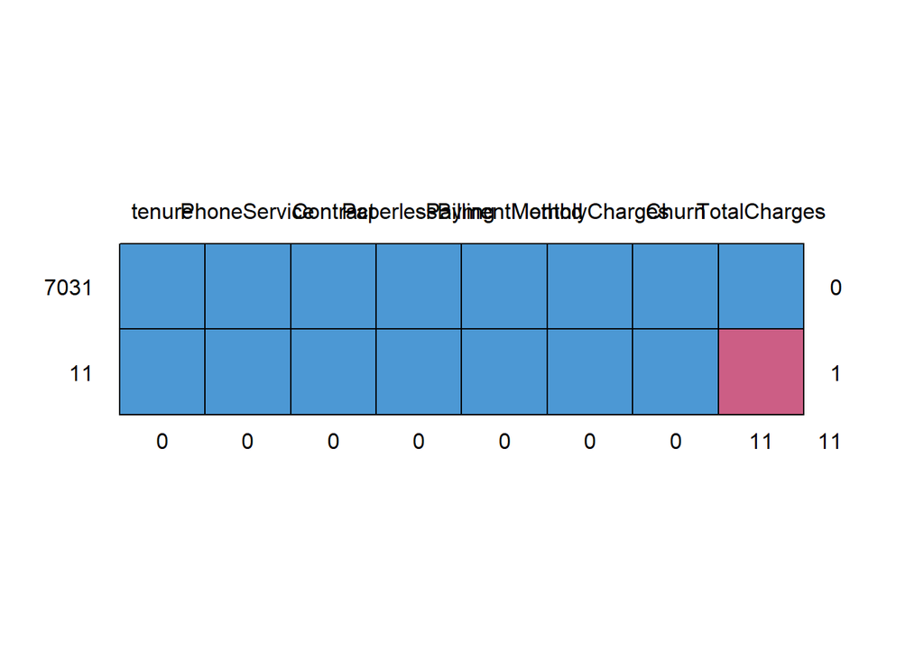

```
##      tenure PhoneService Contract PaperlessBilling PaymentMethod MonthlyCharges
## 7031      1            1        1                1             1              1
## 11        1            1        1                1             1              1
##           0            0        0                0             0              0
##      Churn TotalCharges
## 7031     1            1  0
## 11       1            0  1
##          0           11 11
```

```r
md.pattern(veriseti)
```

```r
sum(is.na(veriseti))
```

```
## [1] 11
```

```r
sum(is.na(veriseti$TotalCharges))
```

```
## [1] 11
```

```r
which(is.na(veriseti$TotalCharges))
```

```
##  [1]  489  754  937 1083 1341 3332 3827 4381 5219 6671 6755
```

Verisetimde toplam 11 eksik gözlemin olduğunu ve bunların tamamının TotalCharges değişkeninde olduğunu gördüm. Eksik gözlemlerin indekslerini de tespit ettim. Verisetimdeki kategorik değişkenleri factor olarak atayıp eksik gözlemlerimi doldurmak istiyorum.

## Kategorik Değişkenlerin Factor Olarak Atanması

```r
veriseti$Churn<-factor(veriseti$Churn)
veriseti$PhoneService<-factor(veriseti$PhoneService)
veriseti$Contract<-factor(veriseti$Contract)
veriseti$PaperlessBilling<-factor(veriseti$PaperlessBilling)
veriseti$PaymentMethod<-factor(veriseti$PaymentMethod)
class(veriseti$Churn);class(veriseti$PhoneService);class(veriseti$Contract);class(veriseti$PaperlessBilling);class(veriseti$PaymentMethod)
```

```
## [1] "factor"
```

```
## [1] "factor"
```

```
## [1] "factor"
```

```
## [1] "factor"
```

```
## [1] "factor"
```

## Eksik Gözlemleri Doldurma İşlemi

```r
imputed<-mice(veriseti, m=5)
imputed$imp
```

```
## $tenure
## [1] 1 2 3 4 5
## <0 rows> (or 0-length row.names)
##
## $PhoneService
## [1] 1 2 3 4 5
## <0 rows> (or 0-length row.names)
##
## $Contract
## [1] 1 2 3 4 5
## <0 rows> (or 0-length row.names)
##
## $PaperlessBilling
## [1] 1 2 3 4 5
## <0 rows> (or 0-length row.names)
##
## $PaymentMethod
## [1] 1 2 3 4 5
## <0 rows> (or 0-length row.names)
##
## $MonthlyCharges
## [1] 1 2 3 4 5
## <0 rows> (or 0-length row.names)
##
## $TotalCharges
##           1      2      3      4      5
## 489  191.05 308.25 221.70  53.55 294.95
## 754   24.05  58.15  86.60  63.75  86.60
## 937  185.55 908.75  93.55 647.50 679.30
## 1083  63.60  55.25  58.30  58.00  63.60
## 1341 238.50 220.45 160.85 692.10 114.10
## 3332 137.60  24.80  68.80  85.50  38.25
## 3827  60.65  40.25  61.70  79.80 159.35
## 4381  63.75  59.75 137.60  68.80  67.10
## 5219  19.65 156.25  77.50  32.70  19.55
## 6671 797.10 844.45 717.30 418.40 158.40
## 6755 234.85 238.50 566.10 416.45 400.00
##
## $Churn
## [1] 1 2 3 4 5
## <0 rows> (or 0-length row.names)
```

```
##  /\     /\
## {  `---'  }
## {  O   O  }
## ==>  V <==  No need for mice. This data set is completely observed.
##  \  \|/  /
##   `-----'
```

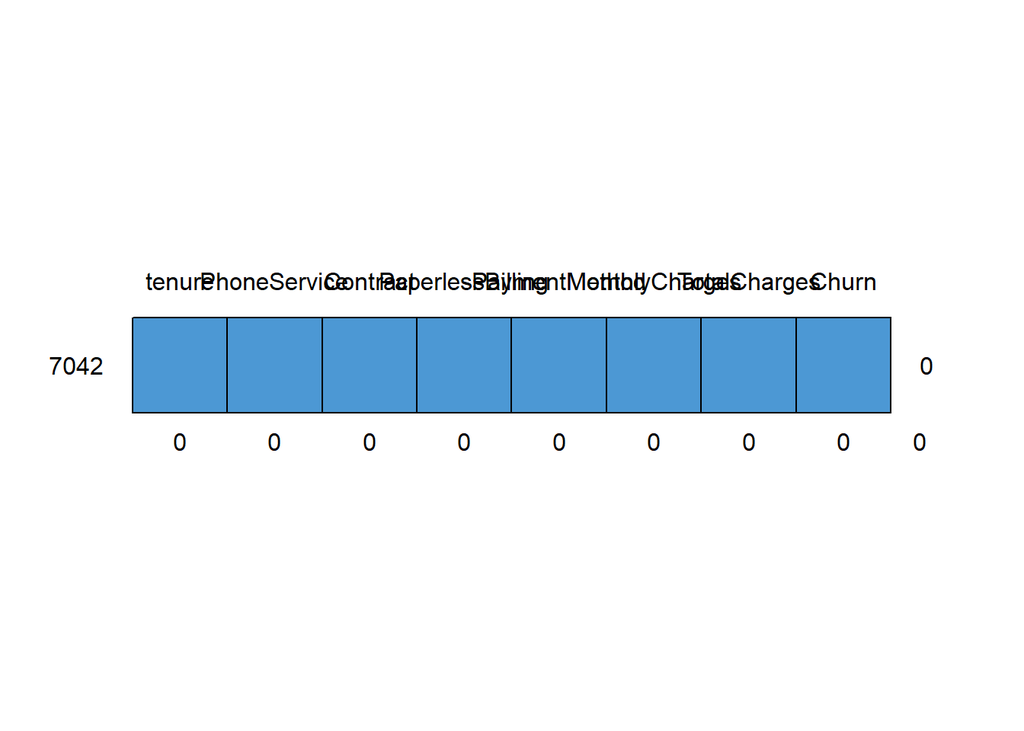

```
##      tenure PhoneService Contract PaperlessBilling PaymentMethod MonthlyCharges
## 7042      1            1        1                1             1              1
##           0            0        0                0             0              0
##      TotalCharges Churn
## 7042            1     1 0
##                 0     0 0
```

```r
veriseti_imp<-complete(imputed, 4)
md.pattern(veriseti_imp)
```

```r
sum(is.na(veriseti_imp))
```

```
## [1] 0
```

```r
View(veriseti_imp)
```

m=5, iterasyon sayısını temsil ediyor. Yani biz bu adımda, her bir değişkende buluna NA degerlerini dolduracağımız imput değeri hesaplatıyoruz. m=5 verdiğimiz için bu değerleri her bir değişken için 5 kere oluşturuyor. Elde edilen bu değerlerden herhangi birini seçip eksik gözlemleri doldurabiliriz. İsteğimize bağlı olarak bu değerlerin ortalamasını veya medyanını da kullanabiliriz. Ben bu adımda, 4. değerler ile doldurmayı tercih ettim.

## Veriyi, Eğitim Verisi ve Test Verisi Olarak Ayırma

```r
table(veriseti_imp$Churn)
```

```
##
##   No  Yes
## 5173 1869
```

```r
dataNoChurn<-veriseti_imp %>% filter(Churn=="No")
dataYesChurn<-veriseti_imp %>% filter(Churn=="Yes")

set.seed(155)
dataNoChurnIndex<-sample(1:nrow(dataNoChurn),size=0.75*nrow(dataNoChurn))
set.seed(155)
dataYesChurnIndex<-sample(1:nrow(dataYesChurn),size=0.75*nrow(dataYesChurn))
trainNoChurn<-dataNoChurn[dataNoChurnIndex,]
trainYesChurn<-dataYesChurn[dataYesChurnIndex,]

trainset<-rbind(trainNoChurn, trainYesChurn)

testNoChurn<-dataNoChurn[-dataNoChurnIndex,]
testYesChurn<-dataYesChurn[-dataYesChurnIndex,]

testset<-rbind(testNoChurn, testYesChurn)


table(testset$Churn)
```

```
##
##   No  Yes
## 1294  468
```

```r
table(trainset$Churn)
```

```
##
##   No  Yes
## 3879 1401
```

Churn değişkenimin değerleri 0 ve 1’lerden oluşuyor. 0’ın sonucu No, 1’in sonucu da Yes olarak gözüküyor. No değeri, müşterinin telekom firmasını kullanmaya devam edeceğini; Yes değeri, müşterinin telekom firmasını kullanmaya devam etmeyeceğini gösteriyor.

Verisetimde Churn değeri No olan 5173 tane, Churn değeri Yes olan 1869 tane gözlem var. Verisetimi eğitim ve test verisi olarak ayırırken eşit oranlarda No Churn ve Yes Churn içermesi için öncelikle verimi, Churn sonucu No olanlar ve Yes olanlar olarak 2’ye ayırdım.

Veriyi %75 eğitim verisi %25 test verisi olarak ayırdım.

Öncelikle Yes Churn değerlerine sahip olan gözlemlerin %75’ini içeren bir veriseti ve No Churn değerlerine sahip olan gözlemlerin %75’ini içeren veriseti oluşturdum. Sonrasında bu iki verisetini birleştirip eğitim verisetini oluşturdum.

Test verisetini oluştururken de, eğitim verisini oluşturduğum gözlemlerden geri kalan gözlemleri kullandım. Bu sayede eğitim verisindeki ve test verisindeki No Churn ve Yes Churn içeren gözlem sayılarının oranının eşit olmasını sağladım.

## İlk Modeli Kurma

```r
trainset$Churn<-relevel(trainset$Churn, ref="No")
model<-glm(Churn~., family = "binomial", data=trainset)
summary(model)
```

```
##
## Call:
## glm(formula = Churn ~ ., family = "binomial", data = trainset)
##
## Deviance Residuals:
##     Min       1Q   Median       3Q      Max
## -1.8224  -0.7039  -0.2744   0.7939   3.2756
##
## Coefficients:
##                                        Estimate Std. Error z value Pr(>|z|)
## (Intercept)                          -8.891e-01  2.054e-01  -4.328 1.50e-05 ***
## tenure                               -6.695e-02  7.293e-03  -9.180  < 2e-16 ***
## PhoneServiceYes                      -7.979e-01  1.426e-01  -5.597 2.18e-08 ***
## ContractOne year                     -9.494e-01  1.219e-01  -7.787 6.87e-15 ***
## ContractTwo year                     -2.017e+00  2.083e-01  -9.683  < 2e-16 ***
## PaperlessBillingYes                   4.403e-01  8.408e-02   5.237 1.63e-07 ***
## PaymentMethodCredit card (automatic)  1.795e-02  1.297e-01   0.138    0.890
## PaymentMethodElectronic check         4.924e-01  1.072e-01   4.595 4.32e-06 ***
## PaymentMethodMailed check            -8.503e-02  1.305e-01  -0.652    0.515
## MonthlyCharges                        2.117e-02  2.346e-03   9.025  < 2e-16 ***
## TotalCharges                          3.762e-04  8.108e-05   4.640 3.49e-06 ***
## ---
## Signif. codes:  0 '***' 0.001 '**' 0.01 '*' 0.05 '.' 0.1 ' ' 1
##
## (Dispersion parameter for binomial family taken to be 1)
##
##     Null deviance: 6109.7  on 5279  degrees of freedom
## Residual deviance: 4453.4  on 5269  degrees of freedom
## AIC: 4475.4
##
## Number of Fisher Scoring iterations: 6
```

```r
anova(model)
```

```
## Analysis of Deviance Table
##
## Model: binomial, link: logit
##
## Response: Churn
##
## Terms added sequentially (first to last)
##
##
##                  Df Deviance Resid. Df Resid. Dev
## NULL                              5279     6109.7
## tenure            1   712.21      5278     5397.5
## PhoneService      1     2.44      5277     5395.0
## Contract          2   406.22      5275     4988.8
## PaperlessBilling  1   132.95      5274     4855.9
## PaymentMethod     3   141.10      5271     4714.8
## MonthlyCharges    1   238.98      5270     4475.8
## TotalCharges      1    22.43      5269     4453.4
```

```r
varImp(model)
```

```
##                                        Overall
## tenure                               9.1800957
## PhoneServiceYes                      5.5970875
## ContractOne year                     7.7869193
## ContractTwo year                     9.6833229
## PaperlessBillingYes                  5.2368432
## PaymentMethodCredit card (automatic) 0.1383832
## PaymentMethodElectronic check        4.5953013
## PaymentMethodMailed check            0.6516443
## MonthlyCharges                       9.0251229
## TotalCharges                         4.6395482
```

```r
exp(coef(model))
```

```
##                          (Intercept)                               tenure
##                            0.4110165                            0.9352444
##                      PhoneServiceYes                     ContractOne year
##                            0.4502576                            0.3869539
##                     ContractTwo year                  PaperlessBillingYes
##                            0.1331024                            1.5531816
## PaymentMethodCredit card (automatic)        PaymentMethodElectronic check
##                            1.0181135                            1.6362799
##            PaymentMethodMailed check                       MonthlyCharges
##                            0.9184885                            1.0213942
##                         TotalCharges
##                            1.0003763
```

Modelimi kurmadan hemen önce eğitim verisindeki Churn değişkeninin No değerini referans olarak atıyorum. Bağımsız değişkenlerin etkilerini exp(coef(model)) sonuçlarından yorumlarken referans değere göre yani No Churn’e göre yorumlayacağım.

Modelin sonuçlarına baktığımızda, PaymentMethodCredit card (automatic) ve PaymentMethodMailed check değişkenlerinin p değeri 0.05’ten yüksek çıktığı için anlamsız olduğunu, diğer değişkenlerin anlamlı olduğunu yani Churn değişkenindeki değişimi açıkladığını anlıyoruz.

Coefficients kısmından Estimate değerlerine baktığımızda ise kurulan denklemin katsayılarını görüyoruz. -0.8889-0.066X1-0.7980X2… şeklinde bir denklem kurulmuş. Yani bu kısımda beta_i değerlerini görüyoruz. Bağımsız değişkenlerin etkilerini ise exp(coef(model)) sonuçları ile göreceğiz.

Anova sonuçlarına baktığımızda öncelikle NULL değerini yani modele değişken eklemeden önceki Residual Deviance değerini 6109 olarak görüyoruz. Residual deviance değerinin yani sapma kalıntının az olması iyi durum. İkinci basamakta modele tenure değişkeninin eklenmesiyle oluşan Residual deviance değerini 5397 olarak görüyoruz. tenure değişkeninin eklenmesi modeli iyileştirmiş. Bu şekilde her eklenen bağımsız değişken için hesaplanan Residual deviance değerini görüyoruz. Anova sonuçlarından, değişkenlerin modele olan etkilerini görmüş olduk.

VarImp sonuçlarına baktığımızda, Overall değeri yüksek olan değişkenlerin modele çok etki ettiğini görüyoruz.

Exp(coef(model)) sonuçlarına baktığımızda ise odds oranlarını görüyoruz. Bir değişkenin odds oranı 1’e yakınsa etki yok, 1’den yüksekse arttirici etkiye sahip, 1’den azsa azaltıcı etkiye sahip olduğunu anlıyoruz.

Diğer değişkenlerdeki artış sonucunun, müşterinin telekom firmasını kullanmaya devam etmesinin devam etmemesine göre nasıl etkilediğini de benzer şekilde yorumlayabiliriz.

## İlk Model Üzerinden Predictlerin Hesaplanması ve Confusion Matrislerin Oluşturulması

```r
predict1<-predict(model, testset, type="response")
summary(predict1)
```

```
##      Min.   1st Qu.    Median      Mean   3rd Qu.      Max.
## 0.0005014 0.0423242 0.1886501 0.2585834 0.4533654 0.8042569
```

```r
cm<-InformationValue::confusionMatrix(testset$Churn,predictedScores=predict1)
cm
```

```
##     No Yes
## 0 1168 219
## 1  126 249
```

```r
optCutoff<-InformationValue::optimalCutoff(testset$Churn, predictedScores=predict1)
optCutoff
```

```
## [1] 0.004256907
```

```r
cmOpt<-InformationValue::confusionMatrix(testset$Churn, predictedScores = predict1>optCutoff)
cmOpt
```

```
##     No Yes
## 0  123   3
## 1 1171 465
```

İlk oluşturulan confusion matris sonuçları incelendiğinde, modelimizin toplamda 1294 NoChurn gözleminin 1168’ini NoChurn olaran tahmin ettiği, 468 YesChurn gözleminin ise sadece 249’unu YesChurn olarak tahmin ettiği görülüyor.

YesChurn tahmin edilmek isteniyorsa OptimallCutOff’a göre oluşturulan confusion matrisin çok daha iyi olduğu söylenebilir. NoChurn tahmin edilmek isteniyorsa ilk oluşturulan confusion matrisin daha iyi olduğu söylenebilir. Ben NoChurn tahminini en iyi şekilde yapan modeli oluşturmaya çalışıyorum.

## ROC Eğrisi

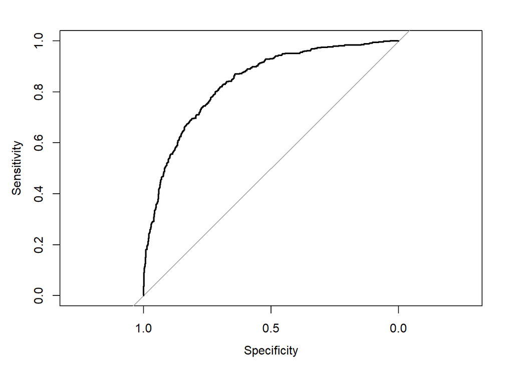

```r
rocModel<-roc(testset$Churn~predict1)
plot(rocModel)
```

```r
rocModel
```

```
##
## Call:
## roc.formula(formula = testset$Churn ~ predict1)
##
## Data: predict1 in 1294 controls (testset$Churn No) < 468 cases (testset$Churn Yes).
## Area under the curve: 0.8361
```

Modelimizin ROC değeri 0.8361 olarak görülüyor. 0.8’in üzerindeki değerler, modelin hedef değişkeni oluşturan iki kategoriyi ayırt etmede iyi bir iş çıkardığını gösterir. Yani modelimizin NoChurn ve YesChurn’ü bulmada iyi iş çıkardığını söyleyebiliriz.

## İlk Model için Değerlendirme Metricleri

```r
predictClass<-ifelse(predict1>0.5,"Yes","No")
predictClass<-as.factor(predictClass)
caret::confusionMatrix(predictClass, reference=testset$Churn)
```

```
## Confusion Matrix and Statistics
##
##           Reference
## Prediction   No  Yes
##        No  1168  219
##        Yes  126  249
##
##                Accuracy : 0.8042
##                  95% CI : (0.7849, 0.8225)
##     No Information Rate : 0.7344
##     P-Value [Acc > NIR] : 4.624e-12
##
##                   Kappa : 0.4641
##
##  Mcnemar's Test P-Value : 7.304e-07
##
##             Sensitivity : 0.9026
##             Specificity : 0.5321
##          Pos Pred Value : 0.8421
##          Neg Pred Value : 0.6640
##              Prevalence : 0.7344
##          Detection Rate : 0.6629
##    Detection Prevalence : 0.7872
##       Balanced Accuracy : 0.7173
##
##        'Positive' Class : No
##
```

```r
predictClass1<-ifelse(predict1>optCutoff, "Yes", "No")
predictClass1<-as.factor(predictClass1)
caret::confusionMatrix(predictClass1, reference=testset$Churn)
```

```
## Confusion Matrix and Statistics
##
##           Reference
## Prediction   No  Yes
##        No   123    3
##        Yes 1171  465
##
##                Accuracy : 0.3337
##                  95% CI : (0.3117, 0.3563)
##     No Information Rate : 0.7344
##     P-Value [Acc > NIR] : 1
##
##                   Kappa : 0.0493
##
##  Mcnemar's Test P-Value : <2e-16
##
##             Sensitivity : 0.09505
##             Specificity : 0.99359
##          Pos Pred Value : 0.97619
##          Neg Pred Value : 0.28423
##              Prevalence : 0.73439
##          Detection Rate : 0.06981
##    Detection Prevalence : 0.07151
##       Balanced Accuracy : 0.54432
##
##        'Positive' Class : No
##
```

İlk oluşturulan confusion matris sonuçlarından Accuracy değerine bakıldığında 0.8042 olarak görülüyor. Bu değer, modelimizin NoChurn olarak tahmin ettikleri ile modelimizin YesChurn olarak tahmin ettiklerinin toplamının tüm değerlere oranını veriyor. Yani modelimizin doğru tahmin etme oranını veriyor. Biz accuracy değerinin 0.8’den yukarıda olmasını bekliyoruz. İlk oluşturulan confusion matris sonucuna göre elde edilen 0.8042 accuracy değeri kabul edilebilir denebilir.

Kappa değeri 0.4641 olarak elde edilmiş. Kappa değeri de modelin performansını gösteren bir değerdir. 0.4 civarında olması ortalama iyi performansı işaret eder. Modelimiz ortalama iyi performansa sahiptir diyebiliriz.

McNemar pvalue>0.05 False Positive ve False Negative birbirine benzerdir. İlk confusion matris sonucunda elde edilen McNemar değeri çok küçük bir değer olduğu için False Positive ve False Negative birbirine benzer değildir denebilir.

Sesitivity değeri 0.9026 olarak elde edilmiş. Sensitivity, modelin NoChurn olarak tahmin ettiklerinin gerçekte NoChurn olanlara oranını veriyor. Yani modelin NoChurn değerini ne kadar iyi tahmin ettiğini gösteriyor. 0.9026 olarak elde edilen Sensitivity değerine göre modelimiz NoChurn gözlemlerini çok iyi bir şekilde tahmin edebiliyor. Ben de NoChurn tahmini iyi olan bir model oluşturmak istediğim için bu model için sensitivity değeri gayet iyi diyebilirim.

Specificity değeri 0.5321 olarak elde edilmiş. Specificity, modelin YesChurn olarak tahmin ettiklerinin gerçekte YesChurn olanlara oranını veriyor. Yani modelin YesChurn değerini ne kadar iyi tahmin ettiğini gösteriyor. 0.5321 olarak elde edilen Specificity değerine göre modelimiz YesChurn gözlemlerini kötü bir şekilde tahmin edebiliyor.

Neg Pred Value değeri 0.6640 olarak elde edilmiş. Bu değer de YesChurn tahmininin kötü olduğunu gösteriyor. Specificity sonucunu destekliyor.

CutOffOptimal’e göre oluşturulan ikinci confusion matris sonucunda accuracy değeri 0.3337 olarak elde edilmiş. Modelin doğru tahminlerinin çok düştüğü görülüyor.

Kappa değeri de 0.0493’lere gerilemiş. Kabul edilemeyecek seviyelerde denebilir.

Sensitivity değerinin de 0.09’lara gerilediği görülüyor. Modelimizin CutOffOptimal’e göre olşturulan confusion matris sonucuna göre NoChurn gözlemlerini çok kötü tahmin ettiği söylenebilir.

Specificity değerinin 0.99359’a yükseldiği görülüyor. Modelimizin YesChurn gözlemlerinin neredeyse tamamını doğru tahmin ettiği söylenebilir.

Ben NoChurn değerini iyi tahmin etmesini istediğim için ilk oluşturulan confusion matrisin sonuçlarını dikkate alacağım.

## Pozitive Class’ı Değiştirip Metricleri İnceleme

```r
predictClass<-ifelse(predict1>0.5, "Yes","No")
predictClass<-as.factor(predictClass)
caret::confusionMatrix(predictClass, reference=testset$Churn,positive="Yes")
```

```
## Confusion Matrix and Statistics
##
##           Reference
## Prediction   No  Yes
##        No  1168  219
##        Yes  126  249
##
##                Accuracy : 0.8042
##                  95% CI : (0.7849, 0.8225)
##     No Information Rate : 0.7344
##     P-Value [Acc > NIR] : 4.624e-12
##
##                   Kappa : 0.4641
##
##  Mcnemar's Test P-Value : 7.304e-07
##
##             Sensitivity : 0.5321
##             Specificity : 0.9026
##          Pos Pred Value : 0.6640
##          Neg Pred Value : 0.8421
##              Prevalence : 0.2656
##          Detection Rate : 0.1413
##    Detection Prevalence : 0.2128
##       Balanced Accuracy : 0.7173
##
##        'Positive' Class : Yes
##
```

```r
predictClass1<-ifelse(predict1>optCutoff, "Yes","No")
predictClass1<-as.factor(predictClass1)
caret::confusionMatrix(predictClass1, reference=testset$Churn,positive="Yes")
```

```
## Confusion Matrix and Statistics
##
##           Reference
## Prediction   No  Yes
##        No   123    3
##        Yes 1171  465
##
##                Accuracy : 0.3337
##                  95% CI : (0.3117, 0.3563)
##     No Information Rate : 0.7344
##     P-Value [Acc > NIR] : 1
##
##                   Kappa : 0.0493
##
##  Mcnemar's Test P-Value : <2e-16
##
##             Sensitivity : 0.99359
##             Specificity : 0.09505
##          Pos Pred Value : 0.28423
##          Neg Pred Value : 0.97619
##              Prevalence : 0.26561
##          Detection Rate : 0.26390
##    Detection Prevalence : 0.92849
##       Balanced Accuracy : 0.54432
##
##        'Positive' Class : Yes
##
```

Pozitive class Yes olarak değiştirilip oluşturulan ilk confusion matrisin sonucuna bakıldığında Accuracy 0.8042 olarak hesaplanmış. Modelimizin doğru tahminlerinin yeterli seviyede olduğu söylenebilir.

Kappa değeri de 0.4641 olarak hesaplanmış. Kappa değerine göre de modelin performansının ortalama iyi seviyede olduğu söylenebilir.

Sensitivity değeri 0.5321 olarak hesaplanmış. Modelin YesChurn gözlemlerini iyi bir şekilde tahmin edemediği söylenebilir.

Specificity 0.9026 olarak hesaplanmış. Modelin NoChurn gözlemlerini iyi bir şekilde tahmin ettiği söylenebilir.

Pozitive class Yes olarak değiştirilip OptimalCutOff’a göre oluşturulan confusion matrisin sonucuna bakıldığında Accuracy 0.337 olarak hespalanmış. Modelin doğru tahminlerinin çok düştüğü görülüyor.

Kappa değeri de 0.0493’lere gerilemiş. Çok düşük seviyede denebilir.

Sensitivity değeri 0.99359 olarak hespalanmış. Modelin pozitive class olan YesChurn’ü çok iyi tahmin ettiği söylenebilir.

Specificity değeri 0.09505 olarak hesaplanmış. Modelin negative class olan NoChurn’ü çok kötü tahmin ettiği söylenebilir.

## Precision Recall ve F1 Metriclerinin Olduğu Confusion Matris Üzerinden İlk Modelin Değerlendirilmesi

```r
predictClass<-ifelse(predict1>0.5, "Yes","No")
predictClass<-as.factor(predictClass)
caret::confusionMatrix(predictClass, reference=testset$Churn,positive="Yes",mode="prec_recall")
```

```
## Confusion Matrix and Statistics
##
##           Reference
## Prediction   No  Yes
##        No  1168  219
##        Yes  126  249
##
##                Accuracy : 0.8042
##                  95% CI : (0.7849, 0.8225)
##     No Information Rate : 0.7344
##     P-Value [Acc > NIR] : 4.624e-12
##
##                   Kappa : 0.4641
##
##  Mcnemar's Test P-Value : 7.304e-07
##
##               Precision : 0.6640
##                  Recall : 0.5321
##                      F1 : 0.5907
##              Prevalence : 0.2656
##          Detection Rate : 0.1413
##    Detection Prevalence : 0.2128
##       Balanced Accuracy : 0.7173
##
##        'Positive' Class : Yes
##
```

Oluşturulan confusion matris sonuçlarına bakıldığında Accuracy 0.8042 olarak hesaplanmış. Modelin doğru tahminlerinin yeterli seviyede olduğu söylenebilir.

Kappa değeri 0.4641 olarak hesaplanmış. Modelin performansı ortalama iyi seviyede denebilir.

Precision değeri, modelin YesChurn olarak tahmin ettiği ve gerçekte de YesChurn olan gözlemlerin, modelin tüm YesChurn tahminlerine oranını veriyor. Yani modelimizin YesChurn gözlemlerini ne kadar iyi tahmin ettiğini gösteren bir metrictir. 0.6640 olarak hesaplanmış. Modelin YesChurn gözlemlerini çok da iyi tahmin edemediği söylenebilir.

Recall değeri, modelimizin YesChurn olarak tahmin ettiği ve gerçekte de YesChurn olan gözlemlerin, gerçekteki tüm YesChurn gözlemlerine oranını veriyor. Modelimizin YesChurn gözlemlerini ne kadar iyi tahmin ettiğini gösteren bir metrictir. 0.5321 olarak hesaplanmış. Modelin YesChurn gözlemlerini iyi tahmin edemediği söylenebilir.

F1 değeri de Precision ve Recall değerlerinin harmanlanmış hali denebilir. 0.5907 olarak hesaplanmış. Modelimizin Pozitive class olan YesChurn’ü iyi tahmin edemediğini gösteriyor.

## Anlamsız Değişkenlerin Modelden Çıkartılıp Yeni Modelin Kurulması

```r
summary(model)
```

```
##
## Call:
## glm(formula = Churn ~ ., family = "binomial", data = trainset)
##
## Deviance Residuals:
##     Min       1Q   Median       3Q      Max
## -1.8224  -0.7039  -0.2744   0.7939   3.2756
##
## Coefficients:
##                                        Estimate Std. Error z value Pr(>|z|)
## (Intercept)                          -8.891e-01  2.054e-01  -4.328 1.50e-05 ***
## tenure                               -6.695e-02  7.293e-03  -9.180  < 2e-16 ***
## PhoneServiceYes                      -7.979e-01  1.426e-01  -5.597 2.18e-08 ***
## ContractOne year                     -9.494e-01  1.219e-01  -7.787 6.87e-15 ***
## ContractTwo year                     -2.017e+00  2.083e-01  -9.683  < 2e-16 ***
## PaperlessBillingYes                   4.403e-01  8.408e-02   5.237 1.63e-07 ***
## PaymentMethodCredit card (automatic)  1.795e-02  1.297e-01   0.138    0.890
## PaymentMethodElectronic check         4.924e-01  1.072e-01   4.595 4.32e-06 ***
## PaymentMethodMailed check            -8.503e-02  1.305e-01  -0.652    0.515
## MonthlyCharges                        2.117e-02  2.346e-03   9.025  < 2e-16 ***
## TotalCharges                          3.762e-04  8.108e-05   4.640 3.49e-06 ***
## ---
## Signif. codes:  0 '***' 0.001 '**' 0.01 '*' 0.05 '.' 0.1 ' ' 1
##
## (Dispersion parameter for binomial family taken to be 1)
##
##     Null deviance: 6109.7  on 5279  degrees of freedom
## Residual deviance: 4453.4  on 5269  degrees of freedom
## AIC: 4475.4
##
## Number of Fisher Scoring iterations: 6
```

Model sonuçları incelendiğinde PeymentMethod değişkeninin Credit card (automatic) ve Mailed check değişkenleri anlamsız gözüküyor. Credit card (automatic) değişkeni modelden çıkartılıp yeni model kurulabilir.

```r
veriseti_imp2<-veriseti_imp[veriseti_imp$PaymentMethod !="Credit card (automatic)", ]
veriseti_imp2$PaymentMethod<-factor(veriseti_imp2$PaymentMethod)
nrow(veriseti_imp2)
```

```
## [1] 5520
```

```r
nrow(veriseti_imp)
```

```
## [1] 7042
```

Credit card (automatic) değerine sahip gözlemler veriden çıkarıldığında gözlem sayımız 7042’den 5520’ye düştü.

Yeni verisetimi eğitim ve test olarak ayırıp yeni modeli kuracağım.

## Veriyi Eğitim ve Test Set Olarak Ayırma

```r
dataNoChurn2<-veriseti_imp2 %>% filter(Churn=="No")
dataYesChurn2<-veriseti_imp2 %>% filter(Churn=="Yes")

set.seed(155)
dataNoChurnIndex2<-sample(1:nrow(dataNoChurn2),size=0.75*nrow(dataNoChurn2))
set.seed(155)
dataYesChurnIndex2<-sample(1:nrow(dataYesChurn2),size=0.75*nrow(dataYesChurn2))
trainNoChurn2<-dataNoChurn2[dataNoChurnIndex2,]
trainYesChurn2<-dataYesChurn2[dataYesChurnIndex2,]

trainset2<-rbind(trainNoChurn2, trainYesChurn2)

testNoChurn2<-dataNoChurn2[-dataNoChurnIndex2,]
testYesChurn2<-dataYesChurn2[-dataYesChurnIndex2,]

testset2<-rbind(testNoChurn2, testYesChurn2)
```

Eğitim ve test olarak ayırırken NoChurn ve YesChurn oranlarının eğitim ve test setinde eşit olması için öncelikle verisetimin gözlemlerini YesChurn ve NoChurn değerlerinin olduğu gözlemler olarak ikiye ayırdım. Sonra YesChurn ve NoChurn değerlerini alan gözlemlerin %75’ini kullanarak eğitim setini, %25’ini kullanarak test setini oluşturdum.

## İkinci Modeli Kurma

```r
model2<-glm(Churn~., family = "binomial", data=trainset2)
summary(model2)
```

```
##
## Call:
## glm(formula = Churn ~ ., family = "binomial", data = trainset2)
##
## Deviance Residuals:
##     Min       1Q   Median       3Q      Max
## -1.8994  -0.7348  -0.2887   0.8289   3.4532
##
## Coefficients:
##                                 Estimate Std. Error z value Pr(>|z|)
## (Intercept)                   -7.193e-01  2.207e-01  -3.259 0.001117 **
## tenure                        -5.976e-02  8.047e-03  -7.426 1.12e-13 ***
## PhoneServiceYes               -9.428e-01  1.549e-01  -6.086 1.16e-09 ***
## ContractOne year              -1.060e+00  1.397e-01  -7.587 3.28e-14 ***
## ContractTwo year              -1.857e+00  2.365e-01  -7.853 4.07e-15 ***
## PaperlessBillingYes            4.371e-01  9.255e-02   4.723 2.32e-06 ***
## PaymentMethodElectronic check  3.609e-01  1.082e-01   3.334 0.000855 ***
## PaymentMethodMailed check     -2.781e-01  1.337e-01  -2.081 0.037420 *
## MonthlyCharges                 2.400e-02  2.585e-03   9.286  < 2e-16 ***
## TotalCharges                   2.401e-04  9.027e-05   2.660 0.007816 **
## ---
## Signif. codes:  0 '***' 0.001 '**' 0.01 '*' 0.05 '.' 0.1 ' ' 1
##
## (Dispersion parameter for binomial family taken to be 1)
##
##     Null deviance: 5031.6  on 4138  degrees of freedom
## Residual deviance: 3665.3  on 4129  degrees of freedom
## AIC: 3685.3
##
## Number of Fisher Scoring iterations: 6
```

```r
anova(model2)
```

```
## Analysis of Deviance Table
##
## Model: binomial, link: logit
##
## Response: Churn
##
## Terms added sequentially (first to last)
##
##
##                  Df Deviance Resid. Df Resid. Dev
## NULL                              4138     5031.6
## tenure            1   556.69      4137     4474.9
## PhoneService      1     0.15      4136     4474.7
## Contract          2   343.42      4134     4131.3
## PaperlessBilling  1   127.17      4133     4004.2
## PaymentMethod     2   139.67      4131     3864.5
## MonthlyCharges    1   191.98      4130     3672.5
## TotalCharges      1     7.25      4129     3665.3
```

```r
varImp(model2)
```

```
##                                Overall
## tenure                        7.425924
## PhoneServiceYes               6.085855
## ContractOne year              7.586720
## ContractTwo year              7.852759
## PaperlessBillingYes           4.723165
## PaymentMethodElectronic check 3.334499
## PaymentMethodMailed check     2.081148
## MonthlyCharges                9.286143
## TotalCharges                  2.659937
```

```r
exp(coef(model2))
```

```
##                   (Intercept)                        tenure
##                     0.4871131                     0.9419935
##               PhoneServiceYes              ContractOne year
##                     0.3895293                     0.3464628
##              ContractTwo year           PaperlessBillingYes
##                     0.1560865                     1.5482467
## PaymentMethodElectronic check     PaymentMethodMailed check
##                     1.4345661                     0.7571861
##                MonthlyCharges                  TotalCharges
##                     1.0242904                     1.0002401
```

Modelin sonuçlarına bakıldığında, Coefficients kısmından tüm bağımsız değişkenlerin anlamlı olduğu görülüyor.

Değişkenlerin katsayılarına bakıldığında ise denkelmin -0.72-0.059X1-0.94X2… şeklinde kurulduğu söylenebilir.

Anova sonuçlarından veya varImp sonuçlarından değişkenlerin modele olan etkileri incelenebilir. Kısaca, modele değişken eklendikçe modelin performansının arttığı görülüyor.

Exp(coef(model)) sonuçlarına baktığımızda ise odds oranlarını görüyoruz.

Diğer değişkenlerdeki artış sonucunun, müşterinin telekom firmasını kullanmaya devam etmesinin devam etmemesine göre nasıl etkilediğini de benzer şekilde yorumlayabiliriz.

## İkinci Model Üzerinden Predictlerin Hesaplanması ve Confusion Matrislerin Oluşturulması

```r
predict2<-predict(model2, testset2, type="response")
summary(predict2)
```

```
##      Min.   1st Qu.    Median      Mean   3rd Qu.      Max.
## 0.0007241 0.0538509 0.2420095 0.2980579 0.5265681 0.8204746
```

```r
cm2<-InformationValue::confusionMatrix(testset2$Churn,predictedScores=predict2)
cm2
```

```
##    No Yes
## 0 826 178
## 1 145 232
```

```r
optCutoff2<-InformationValue::optimalCutoff(testset2$Churn, predictedScores=predict2)
optCutoff2
```

```
## [1] 0.01047464
```

```r
cmOpt2<-InformationValue::confusionMatrix(testset2$Churn, predictedScores = predict2>optCutoff2)
cmOpt2
```

```
##    No Yes
## 0 126   2
## 1 845 408
```

Hesaplanan predict değerlerinin sonuçlarına bakıldığında, median değerinin 0.242 olmasından çoğu değerin 0’a daha yakın olduğunu anlıyoruz.

İlk oluşturulan confusion matris sonuçları incelendiğinde, modelimizin toplamda 971 NoChurn gözleminin 826’sını NoChurn olaran tahmin ettiği, 410 YesChurn gözleminin ise sadece 232’sini YesChurn olarak tahmin ettiği görülüyor. NoChurn’ü tahmin etmede daha başarılı olduğu görülüyor.

OtpimalCutOff’a göre oluşturulan confusion matris sonucuna göre YesChurn’lerin neredeyse tamamı YesChurn olarak tahmin edilmiş. NoChurn gözlemlerinin ise çok kötü tahmin edildiği görülüyor.

## ROC Eğrisi

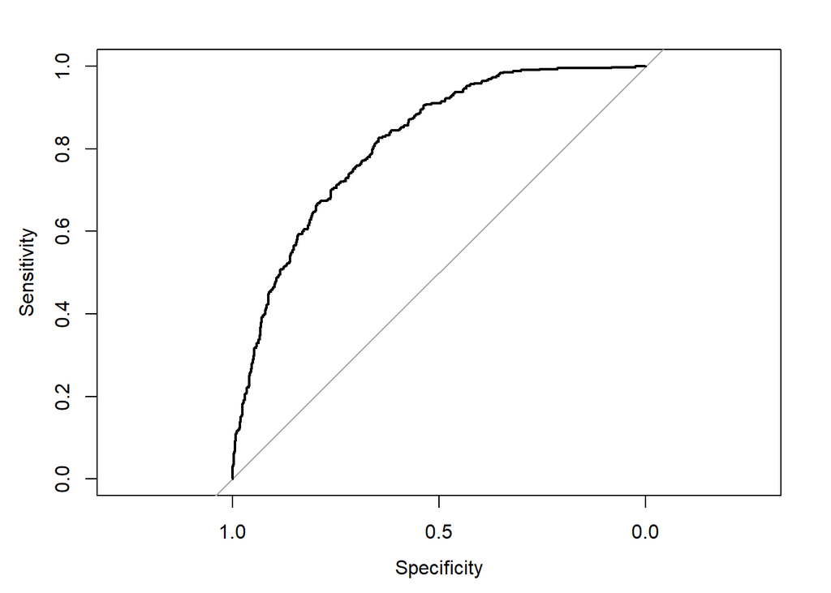

```r
rocModel2<-roc(testset2$Churn~predict2)
plot(rocModel2)
```

```r
rocModel2
```

```
##
## Call:
## roc.formula(formula = testset2$Churn ~ predict2)
##
## Data: predict2 in 971 controls (testset2$Churn No) < 410 cases (testset2$Churn Yes).
## Area under the curve: 0.8135
```

Modelimizin ROC değeri 0.8135 olarak görülüyor. 0.8’in üzerindeki değerler, modelin hedef değişkeni oluşturan iki kategoriyi ayırt etmede iyi bir iş çıkardığını gösterir. Yani modelimizin NoChurn ve YesChurn’ü bulmada iyi iş çıkardığını söyleyebiliriz. İlk modelimize kıyasla biraz düşüş olsa da önemli bir düşüş sayılmaz.

## İkinci Model için Değerlendirme Metricleri

```r
predictClass2<-ifelse(predict2>0.5,"Yes","No")
predictClass2<-as.factor(predictClass2)
caret::confusionMatrix(predictClass2, reference=testset2$Churn)
```

```
## Confusion Matrix and Statistics
##
##           Reference
## Prediction  No Yes
##        No  826 178
##        Yes 145 232
##
##                Accuracy : 0.7661
##                  95% CI : (0.7429, 0.7882)
##     No Information Rate : 0.7031
##     P-Value [Acc > NIR] : 9.517e-08
##
##                   Kappa : 0.4264
##
##  Mcnemar's Test P-Value : 0.07499
##
##             Sensitivity : 0.8507
##             Specificity : 0.5659
##          Pos Pred Value : 0.8227
##          Neg Pred Value : 0.6154
##              Prevalence : 0.7031
##          Detection Rate : 0.5981
##    Detection Prevalence : 0.7270
##       Balanced Accuracy : 0.7083
##
##        'Positive' Class : No
##
```

```r
predictClass2<-ifelse(predict2>optCutoff2, "Yes", "No")
predictClass2<-as.factor(predictClass2)
caret::confusionMatrix(predictClass2, reference=testset2$Churn)
```

```
## Confusion Matrix and Statistics
##
##           Reference
## Prediction  No Yes
##        No  126   2
##        Yes 845 408
##
##                Accuracy : 0.3867
##                  95% CI : (0.3609, 0.4129)
##     No Information Rate : 0.7031
##     P-Value [Acc > NIR] : 1
##
##                   Kappa : 0.0783
##
##  Mcnemar's Test P-Value : <2e-16
##
##             Sensitivity : 0.12976
##             Specificity : 0.99512
##          Pos Pred Value : 0.98437
##          Neg Pred Value : 0.32562
##              Prevalence : 0.70311
##          Detection Rate : 0.09124
##    Detection Prevalence : 0.09269
##       Balanced Accuracy : 0.56244
##
##        'Positive' Class : No
##
```

İlk oluşturulan confusion matris sonuçlarından Accuracy değerine bakıldığında 0.7661 olarak görülüyor. Bu değer, modelimizin NoChurn olarak tahmin ettikleri ile modelimizin YesChurn olarak tahmin ettiklerinin toplamının tüm değerlere oranını veriyor. Yani modelimizin doğru tahmin etme oranını veriyor. Biz accuracy değerinin 0.8’den yukarıda olmasını bekliyoruz. İlk modelimiz’e göre biraz düşük Accuracy değeri elde edildi.

Kappa değeri 0.4264 olarak elde edilmiş. Kappa değeri de modelin performansını gösteren bir değerdir. 0.4 civarında olması ortalama iyi performansı işaret eder. Modelimiz ortalama iyi performansa sahiptir diyebiliriz. Kappa değerinin de ilk modele göre biraz düştüğü görülüyor.

McNemar pvalue>0.05 False Positive ve False Negative birbirine benzerdir. İlk confusion matris sonucunda elde edilen McNemar değeri 0.07499 olduğu için False Positive ve False Negative birbirine benzerdir denebilir.

Sesitivity değeri 0.8507 olarak elde edilmiş. Sensitivity, modelin NoChurn olarak tahmin ettiklerinin gerçekte NoChurn olanlara oranını veriyor. Yani modelin NoChurn değerini ne kadar iyi tahmin ettiğini gösteriyor. 0.8507 olarak elde edilen Sensitivity değerine göre modelimiz NoChurn gözlemlerini iyi bir şekilde tahmin edebiliyor. İlk modele kıyasla Sensitivity değerinde de düşüş var.

Specificity değeri 0.5659 olarak elde edilmiş. Specificity, modelin YesChurn olarak tahmin ettiklerinin gerçekte YesChurn olanlara oranını veriyor. Yani modelin YesChurn değerini ne kadar iyi tahmin ettiğini gösteriyor. 0.5659 olarak elde edilen Specificity değerine göre modelimiz YesChurn gözlemlerini kötü bir şekilde tahmin edebiliyor. İlk modele kıyasla neredeyse eşit Specificity değerine sahip.

Pos Pred Value değeri 0.8227 olarak elde edilmiş. Bu değer de NoChurn tahmininin ne kadar iyi olduğunu gösteriyor. İlk modelle neredeyse aynı sonuç elde edildi.

Neg Pred Value değeri 0.6154 olarak elde edilmiş. Bu değer de YesChurn tahmininin kötü olduğunu gösteriyor. İlk modelle neredeyse aynı sonuç elde edildi.

CutOffOptimal’e göre oluşturulan ikinci confusion matris sonucunda accuracy değeri 0.3867 olarak elde edilmiş. Modelin doğru tahminlerinin çok düştüğü görülüyor.

Kappa değeri de 0.0783’lere gerilemiş. Kappa değerinin çok düşük olduğu söylenebilir.

Sensitivity değerinin de 0.12976’lara gerilediği görülüyor. Modelimizin CutOffOptimal’e göre olşturulan confusion matris sonucuna göre NoChurn gözlemlerini çok kötü tahmin ettiği söylenebilir.

Specificity değerinin 0.99512’ye yükseldiği görülüyor. Modelimizin YesChurn gözlemlerinin neredeyse tamamını doğru tahmin ettiği söylenebilir. Ben NoChurn değerini iyi tahmin etmesini istediğim için ilk oluşturulan confusion matrisin sonuçları daha iyi diyebilirim.

Özetle; modelimiz NoChurn gözlemlerini tahmin etmede ilk modelimize kıyasla daha kötü bir performansa sahip. YesChurn gözlemlerini tahmin etmedeki performansı hemen hemen aynı seviyede. İlk oluşturduğumuz modelin performansının daha iyi olduğu görülüyor.

## Pozitive Class’ı Değiştirip Metricleri İnceleme

```r
predictClass2<-ifelse(predict2>0.5, "Yes","No")
predictClass2<-as.factor(predictClass2)
caret::confusionMatrix(predictClass2, reference=testset2$Churn,positive="Yes")
```

```
## Confusion Matrix and Statistics
##
##           Reference
## Prediction  No Yes
##        No  826 178
##        Yes 145 232
##
##                Accuracy : 0.7661
##                  95% CI : (0.7429, 0.7882)
##     No Information Rate : 0.7031
##     P-Value [Acc > NIR] : 9.517e-08
##
##                   Kappa : 0.4264
##
##  Mcnemar's Test P-Value : 0.07499
##
##             Sensitivity : 0.5659
##             Specificity : 0.8507
##          Pos Pred Value : 0.6154
##          Neg Pred Value : 0.8227
##              Prevalence : 0.2969
##          Detection Rate : 0.1680
##    Detection Prevalence : 0.2730
##       Balanced Accuracy : 0.7083
##
##        'Positive' Class : Yes
##
```

```r
predictClass2<-ifelse(predict2>optCutoff2, "Yes","No")
predictClass2<-as.factor(predictClass2)
caret::confusionMatrix(predictClass2, reference=testset2$Churn,positive="Yes")
```

```
## Confusion Matrix and Statistics
##
##           Reference
## Prediction  No Yes
##        No  126   2
##        Yes 845 408
##
##                Accuracy : 0.3867
##                  95% CI : (0.3609, 0.4129)
##     No Information Rate : 0.7031
##     P-Value [Acc > NIR] : 1
##
##                   Kappa : 0.0783
##
##  Mcnemar's Test P-Value : <2e-16
##
##             Sensitivity : 0.9951
##             Specificity : 0.1298
##          Pos Pred Value : 0.3256
##          Neg Pred Value : 0.9844
##              Prevalence : 0.2969
##          Detection Rate : 0.2954
##    Detection Prevalence : 0.9073
##       Balanced Accuracy : 0.5624
##
##        'Positive' Class : Yes
##
```

Pozitive class Yes olarak değiştirilip oluşturulan ilk confusion matrisin sonucuna bakıldığında Accuracy 0.7661 olarak hesaplanmış. 0.8’in altında olduğu için modelimizin doğru tahminlerinin yeterli seviyede olmadığı söylenebilir.

Kappa değeri de 0.4264 olarak hesaplanmış. Kappa değerine göre de modelin performansının ortalama iyi seviyede olduğu söylenebilir.

Sensitivity değeri 0.5659 olarak hesaplanmış. Modelin YesChurn gözlemlerini iyi bir şekilde tahmin edemediği söylenebilir.

Specificity 0.8507 olarak hesaplanmış. Modelin NoChurn gözlemlerini iyi bir şekilde tahmin ettiği söylenebilir.

Pozitive class Yes olarak değiştirilip OptimalCutOff’a göre oluşturulan confusion matrisin sonucuna bakıldığında Accuracy 0.3867 olarak hespalanmış. Modelin doğru tahminlerinin çok düştüğü görülüyor.

Kappa değeri de 0.0783 ’lere gerilemiş. Çok düşük seviyede denebilir.

Sensitivity değeri 0.9951 olarak hespalanmış. Modelin pozitive class olan YesChurn’ü çok iyi tahmin ettiği söylenebilir.

Specificity değeri 0.1298 olarak hesaplanmış. Modelin negative class olan NoChurn’ü çok kötü tahmin ettiği söylenebilir.

## Precision Recall ve F1 Metriclerinin Olduğu Confusion Matris Üzerinden İkinci Modelin Değerlendirilmesi

```r
predictClass2<-ifelse(predict2>0.5, "Yes","No")
predictClass2<-as.factor(predictClass2)
caret::confusionMatrix(predictClass2, reference=testset2$Churn,positive="Yes",mode="prec_recall")
```

```
## Confusion Matrix and Statistics
##
##           Reference
## Prediction  No Yes
##        No  826 178
##        Yes 145 232
##
##                Accuracy : 0.7661
##                  95% CI : (0.7429, 0.7882)
##     No Information Rate : 0.7031
##     P-Value [Acc > NIR] : 9.517e-08
##
##                   Kappa : 0.4264
##
##  Mcnemar's Test P-Value : 0.07499
##
##               Precision : 0.6154
##                  Recall : 0.5659
##                      F1 : 0.5896
##              Prevalence : 0.2969
##          Detection Rate : 0.1680
##    Detection Prevalence : 0.2730
##       Balanced Accuracy : 0.7083
##
##        'Positive' Class : Yes
##
```

Oluşturulan confusion matris sonuçlarına bakıldığında Accuracy 0.7661 olarak hesaplanmış. 0.8’den düşük bir değer olduğu için yeterli seviyede değil diyebiliriz.

Kappa değeri 0.4264 olarak hesaplanmış. Modelin performansı ortalama iyi seviyede denebilir.

Precision değeri, modelin YesChurn olarak tahmin ettiği ve gerçekte de YesChurn olan gözlemlerin, modelin tüm YesChurn tahminlerine oranını veriyor. Yani modelimizin YesChurn gözlemlerini ne kadar iyi tahmin ettiğini gösteren bir metrictir. 0.6154 olarak hesaplanmış. Modelin YesChurn gözlemlerini iyi tahmin edemediği söylenebilir.

Recall değeri, modelimizin YesChurn olarak tahmin ettiği ve gerçekte de YesChurn olan gözlemlerin, gerçekteki tüm YesChurn gözlemlerine oranını veriyor. Modelimizin YesChurn gözlemlerini ne kadar iyi tahmin ettiğini gösteren bir metrictir. 0.5659 olarak hesaplanmış. Modelin YesChurn gözlemlerini iyi tahmin edemediği söylenebilir.

F1 değeri de Precision ve Recall değerlerinin harmanlanmış hali denebilir. 0.5896 olarak hesaplanmış. Modelimizin Pozitive class olan YesChurn’ü iyi tahmin edemediğini gösteriyor.

## Multicolinearity (Çoklu Bağlantı)

```r
vif(model2)
```

```
##                       GVIF Df GVIF^(1/(2*Df))
## tenure           15.194560  1        3.898020
## PhoneService      1.285392  1        1.133751
## Contract          1.369755  2        1.081834
## PaperlessBilling  1.112957  1        1.054968
## PaymentMethod     1.325453  2        1.072979
## MonthlyCharges    2.816605  1        1.678275
## TotalCharges     18.832110  1        4.339598
```

Vif değerleri modelin varyansini şişiren değişkenleri gösteriyor. Varyansın şişmesi durumunda değişkenlerin anlamlı ya da anlamsız çıkması negatif anlamda etkileniyor. 10’un üzerindeki vif değerlerinin yüksek olduğunu anlıyoruz. 10’un altındaki vif değerleri kabul edilebilir seviyede diyoruz.

TotalCharges değişkeninin vif değeri en yüksek olduğu için öncelikle onu verisetinden çıkartıp yeni bir model kuralım.

```r
veriseti_imp2$TotalCharges<-NULL
```

## Veriyi Eğitim ve Test Set Olarak Ayırma

```r
veriseti_imp2$TotalCharges<-NULL

dataNoChurn3<-veriseti_imp2 %>% filter(Churn=="No")
dataYesChurn3<-veriseti_imp2 %>% filter(Churn=="Yes")

set.seed(155)
dataNoChurnIndex3<-sample(1:nrow(dataNoChurn3),size=0.75*nrow(dataNoChurn3))
set.seed(155)
dataYesChurnIndex3<-sample(1:nrow(dataYesChurn3),size=0.75*nrow(dataYesChurn3))
trainNoChurn3<-dataNoChurn3[dataNoChurnIndex3,]
trainYesChurn3<-dataYesChurn3[dataYesChurnIndex3,]

trainset3<-rbind(trainNoChurn3, trainYesChurn3)

testNoChurn3<-dataNoChurn3[-dataNoChurnIndex3,]
testYesChurn3<-dataYesChurn3[-dataYesChurnIndex3,]

testset3<-rbind(testNoChurn2, testYesChurn2)
```

Diğer adımlarda olduğu gibi bu adımda da %75 eğitim verisi %25 test verisi olarak ayırdım.

## Üçüncü Modeli Kurma

```r
model3<-glm(Churn~., family = "binomial", data=trainset3)
summary(model3)
```

```
##
## Call:
## glm(formula = Churn ~ ., family = "binomial", data = trainset3)
##
## Deviance Residuals:
##     Min       1Q   Median       3Q      Max
## -1.9547  -0.7257  -0.2991   0.8200   3.2613
##
## Coefficients:
##                                Estimate Std. Error z value Pr(>|z|)
## (Intercept)                   -1.061585   0.179508  -5.914 3.34e-09 ***
## tenure                        -0.039935   0.002731 -14.621  < 2e-16 ***
## PhoneServiceYes               -0.892557   0.150982  -5.912 3.39e-09 ***
## ContractOne year              -1.051328   0.138741  -7.578 3.52e-14 ***
## ContractTwo year              -1.794922   0.233080  -7.701 1.35e-14 ***
## PaperlessBillingYes            0.432975   0.092325   4.690 2.74e-06 ***
## PaymentMethodElectronic check  0.370723   0.108172   3.427  0.00061 ***
## PaymentMethodMailed check     -0.238142   0.132231  -1.801  0.07171 .
## MonthlyCharges                 0.027981   0.002135  13.107  < 2e-16 ***
## ---
## Signif. codes:  0 '***' 0.001 '**' 0.01 '*' 0.05 '.' 0.1 ' ' 1
##
## (Dispersion parameter for binomial family taken to be 1)
##
##     Null deviance: 5031.6  on 4138  degrees of freedom
## Residual deviance: 3672.5  on 4130  degrees of freedom
## AIC: 3690.5
##
## Number of Fisher Scoring iterations: 6
```

```r
anova(model3)
```

```
## Analysis of Deviance Table
##
## Model: binomial, link: logit
##
## Response: Churn
##
## Terms added sequentially (first to last)
##
##
##                  Df Deviance Resid. Df Resid. Dev
## NULL                              4138     5031.6
## tenure            1   556.69      4137     4474.9
## PhoneService      1     0.15      4136     4474.7
## Contract          2   343.42      4134     4131.3
## PaperlessBilling  1   127.17      4133     4004.2
## PaymentMethod     2   139.67      4131     3864.5
## MonthlyCharges    1   191.98      4130     3672.5
```

```r
varImp(model3)
```

```
##                                 Overall
## tenure                        14.620861
## PhoneServiceYes                5.911689
## ContractOne year               7.577625
## ContractTwo year               7.700895
## PaperlessBillingYes            4.689690
## PaymentMethodElectronic check  3.427156
## PaymentMethodMailed check      1.800948
## MonthlyCharges                13.107243
```

```r
exp(coef(model3))
```

```
##                   (Intercept)                        tenure
##                     0.3459072                     0.9608521
##               PhoneServiceYes              ContractOne year
##                     0.4096071                     0.3494735
##              ContractTwo year           PaperlessBillingYes
##                     0.1661403                     1.5418383
## PaymentMethodElectronic check     PaymentMethodMailed check
##                     1.4487811                     0.7880909
##                MonthlyCharges
##                     1.0283766
```

Anova ve varImp sonuçlarından da değişkenlerin modele olumlu katkılarının olduğu görülüyor.

Exp(coef(model)) sonuçlarına baktığımızda ise odds oranlarını görüyoruz.

Diğer değişkenlerin odds oranından benzer yorumlar yapılabilir. En son adımda nihai model seçildiğinde tüm değişkenlerin etkilerini söyleyeceğim.

## Üçüncü Model Üzerinden Predictlerin Hesaplanması ve Confusion Matrislerin Oluşturulması

```r
predict3<-predict(model3, testset3, type="response")
summary(predict3)
```

```
##     Min.  1st Qu.   Median     Mean  3rd Qu.     Max.
## 0.001881 0.053726 0.231594 0.297965 0.520713 0.836190
```

```r
cm3<-InformationValue::confusionMatrix(testset3$Churn,predictedScores=predict3)
cm3
```

```
##    No Yes
## 0 828 185
## 1 143 225
```

```r
optCutoff3<-InformationValue::optimalCutoff(testset3$Churn, predictedScores=predict3)
optCutoff3
```

```
## [1] 0.006190121
```

```r
cmOpt3<-InformationValue::confusionMatrix(testset3$Churn, predictedScores = predict3>optCutoff3)
cmOpt3
```

```
##    No Yes
## 0  67   1
## 1 904 409
```

## ROC Eğrisi

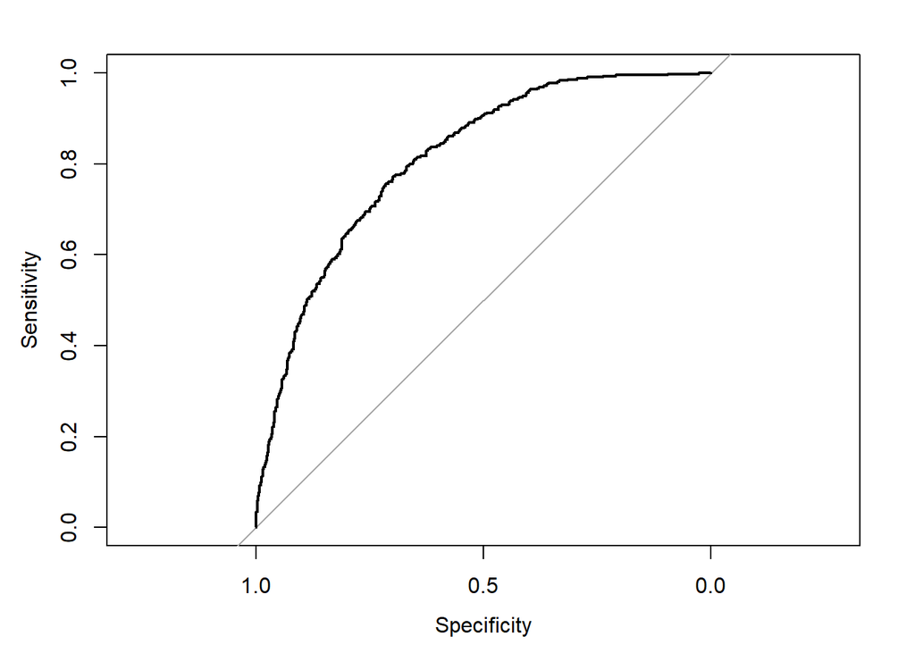

```r
rocModel3<-roc(testset3$Churn~predict3)
plot(rocModel3)
```

```r
rocModel3
```

```
##
## Call:
## roc.formula(formula = testset3$Churn ~ predict3)
##
## Data: predict3 in 971 controls (testset3$Churn No) < 410 cases (testset3$Churn Yes).
## Area under the curve: 0.8103
```

## Üçüncü Model için Değerlendirme Metricleri

```r
predictClass3<-ifelse(predict3>0.5,"Yes","No")
predictClass3<-as.factor(predictClass3)
caret::confusionMatrix(predictClass3, reference=testset3$Churn)
```

```
## Confusion Matrix and Statistics
##
##           Reference
## Prediction  No Yes
##        No  828 185
##        Yes 143 225
##
##                Accuracy : 0.7625
##                  95% CI : (0.7391, 0.7847)
##     No Information Rate : 0.7031
##     P-Value [Acc > NIR] : 4.793e-07
##
##                   Kappa : 0.4138
##
##  Mcnemar's Test P-Value : 0.02358
##
##             Sensitivity : 0.8527
##             Specificity : 0.5488
##          Pos Pred Value : 0.8174
##          Neg Pred Value : 0.6114
##              Prevalence : 0.7031
##          Detection Rate : 0.5996
##    Detection Prevalence : 0.7335
##       Balanced Accuracy : 0.7008
##
##        'Positive' Class : No
##
```

```r
predictClass3<-ifelse(predict3>optCutoff3, "Yes", "No")
predictClass3<-as.factor(predictClass3)
caret::confusionMatrix(predictClass3, reference=testset3$Churn)
```

```
## Confusion Matrix and Statistics
##
##           Reference
## Prediction  No Yes
##        No   67   1
##        Yes 904 409
##
##                Accuracy : 0.3447
##                  95% CI : (0.3196, 0.3704)
##     No Information Rate : 0.7031
##     P-Value [Acc > NIR] : 1
##
##                   Kappa : 0.0407
##
##  Mcnemar's Test P-Value : <2e-16
##
##             Sensitivity : 0.06900
##             Specificity : 0.99756
##          Pos Pred Value : 0.98529
##          Neg Pred Value : 0.31150
##              Prevalence : 0.70311
##          Detection Rate : 0.04852
##    Detection Prevalence : 0.04924
##       Balanced Accuracy : 0.53328
##
##        'Positive' Class : No
##
```

Özetle; modelimiz NoChurn gözlemlerini tahmin etmede ilk modelimize kıyasla daha kötü bir performansa sahip. YesChurn gözlemlerini tahmin etmedeki performansı hemen hemen aynı seviyede. İlk oluşturduğumuz modelin performansının daha iyi olduğu görülüyor.

## Precision Recall ve F1 Metriclerinin Olduğu Confusion Matris Üzerinden Üçüncü Modelin Değerlendirilmesi

```r
predictClass3<-ifelse(predict3>0.5, "Yes","No")
predictClass3<-as.factor(predictClass3)
caret::confusionMatrix(predictClass3, reference=testset3$Churn,positive="Yes",mode="prec_recall")
```

```
## Confusion Matrix and Statistics
##
##           Reference
## Prediction  No Yes
##        No  828 185
##        Yes 143 225
##
##                Accuracy : 0.7625
##                  95% CI : (0.7391, 0.7847)
##     No Information Rate : 0.7031
##     P-Value [Acc > NIR] : 4.793e-07
##
##                   Kappa : 0.4138
##
##  Mcnemar's Test P-Value : 0.02358
##
##               Precision : 0.6114
##                  Recall : 0.5488
##                      F1 : 0.5784
##              Prevalence : 0.2969
##          Detection Rate : 0.1629
##    Detection Prevalence : 0.2665
##       Balanced Accuracy : 0.7008
##
##        'Positive' Class : Yes
##
```

```r
veriseti_imp3<-veriseti_imp2[veriseti_imp2$PaymentMethod!="Mailed check", ]
nrow(veriseti_imp3)
```

```
## [1] 3908
```

```r
nrow(veriseti_imp)
```

```
## [1] 7042
```

Gözlem sayımızın 7042’den 3908’e düştüğü görülüyor.

## Veriyi Eğitim ve Test Set Olarak Ayırma

```r
dataNoChurn4<-veriseti_imp3 %>% filter(Churn=="No")
dataYesChurn4<-veriseti_imp3 %>% filter(Churn=="Yes")

set.seed(155)
dataNoChurnIndex4<-sample(1:nrow(dataNoChurn4),size=0.75*nrow(dataNoChurn4))
set.seed(155)
dataYesChurnIndex4<-sample(1:nrow(dataYesChurn4),size=0.75*nrow(dataYesChurn4))
trainNoChurn4<-dataNoChurn4[dataNoChurnIndex4,]
trainYesChurn4<-dataYesChurn4[dataYesChurnIndex4,]

trainset4<-rbind(trainNoChurn4, trainYesChurn4)

testNoChurn4<-dataNoChurn4[-dataNoChurnIndex4,]
testYesChurn4<-dataYesChurn4[-dataYesChurnIndex4,]

testset4<-rbind(testNoChurn4, testYesChurn4)
```

Daha önceki adımlarda olduğu gibi bu adımda da %75 eğitim verisi %25 test verisi olarak ayırdım.

## Dördüncü Modeli Kurma

```r
model4<-glm(Churn~., family = "binomial", data=trainset4)
summary(model4)
```

```
##
## Call:
## glm(formula = Churn ~ ., family = "binomial", data = trainset4)
##
## Deviance Residuals:
##     Min       1Q   Median       3Q      Max
## -1.8892  -0.8161  -0.3526   0.9179   3.1189
##
## Coefficients:
##                                Estimate Std. Error z value Pr(>|z|)
## (Intercept)                   -1.118809   0.195458  -5.724 1.04e-08 ***
## tenure                        -0.036872   0.002951 -12.495  < 2e-16 ***
## PhoneServiceYes               -0.984324   0.183953  -5.351 8.75e-08 ***
## ContractOne year              -0.862943   0.152324  -5.665 1.47e-08 ***
## ContractTwo year              -1.337822   0.234627  -5.702 1.18e-08 ***
## PaperlessBillingYes            0.417378   0.107054   3.899 9.67e-05 ***
## PaymentMethodElectronic check  0.450703   0.106413   4.235 2.28e-05 ***
## MonthlyCharges                 0.027293   0.002585  10.559  < 2e-16 ***
## ---
## Signif. codes:  0 '***' 0.001 '**' 0.01 '*' 0.05 '.' 0.1 ' ' 1
##
## (Dispersion parameter for binomial family taken to be 1)
##
##     Null deviance: 3756.2  on 2929  degrees of freedom
## Residual deviance: 2894.7  on 2922  degrees of freedom
## AIC: 2910.7
##
## Number of Fisher Scoring iterations: 5
```

```r
anova(model4)
```

```
## Analysis of Deviance Table
##
## Model: binomial, link: logit
##
## Response: Churn
##
## Terms added sequentially (first to last)
##
##
##                  Df Deviance Resid. Df Resid. Dev
## NULL                              2929     3756.2
## tenure            1   507.13      2928     3249.1
## PhoneService      1     0.11      2927     3249.0
## Contract          2   134.42      2925     3114.5
## PaperlessBilling  1    55.13      2924     3059.4
## PaymentMethod     1    36.42      2923     3023.0
## MonthlyCharges    1   128.29      2922     2894.7
```

```r
varImp(model4)
```

```
##                                 Overall
## tenure                        12.495313
## PhoneServiceYes                5.350944
## ContractOne year               5.665201
## ContractTwo year               5.701900
## PaperlessBillingYes            3.898759
## PaymentMethodElectronic check  4.235425
## MonthlyCharges                10.558910
```

```r
exp(coef(model4))
```

```
##                   (Intercept)                        tenure
##                     0.3266687                     0.9637994
##               PhoneServiceYes              ContractOne year
##                     0.3736918                     0.4219184
##              ContractTwo year           PaperlessBillingYes
##                     0.2624165                     1.5179768
## PaymentMethodElectronic check                MonthlyCharges
##                     1.5694155                     1.0276693
```

Modelin sonuçlarından anlamsız değişkenin olmadığı görülüyor.

Anova ve varImp sonuçlarından da değişkenlerin modele olumlu katkılarının olduğu görülüyor.

Exp(coef(model)) sonuçlarına baktığımızda ise odds oranlarını görüyoruz.

Tenure değişkeninin sonucu 0.9637994 olarak görülüyor. Bu sonuca göre bir kişinin NoChurn (telekom firmasını kullanmaya devam eden kişi) olması YesChurn olmasına göre, tenure değişkenindeki (yani kullanım süresindeki) 1 birimlik artış ile 1/(0.9637994) kat azalır.

Diğer değişkenlerin odds oranından benzer yorumlar yapılabilir. En son adımda nihai model seçildiğinde tüm değişkenlerin etkilerini söyleyeceğim.

## Dördüncü Model Üzerinden Predictlerin Hesaplanması ve Confusion Matrislerin Oluşturulması

```r
predict4<-predict(model4, testset4, type="response")
summary(predict4)
```

```
##    Min. 1st Qu.  Median    Mean 3rd Qu.    Max.
## 0.00381 0.08535 0.31653 0.33759 0.57785 0.82415
```

```r
cm4<-InformationValue::confusionMatrix(testset4$Churn,predictedScores=predict4)
cm4
```

```
##    No Yes
## 0 537 122
## 1 108 211
```

```r
optCutoff4<-InformationValue::optimalCutoff(testset4$Churn, predictedScores=predict4)
optCutoff4
```

```
## [1] 0.004148194
```

```r
cmOpt4<-InformationValue::confusionMatrix(testset4$Churn, predictedScores = predict4>optCutoff4)
cmOpt4
```

```
##    No Yes
## 0   6   0
## 1 639 333
```

Predict değerlerinin sonuçlarına bakıldığında median değerinin 0.31653 olmasından çoğu değerin 0’a yakın olduğunu anlıyoruz. Median değerinin, kurduğumuz her model için giderek arttığı görülüyor.

İlk oluşturulan confusion matris sonuçları incelendiğinde, modelimizin toplamda 645 NoChurn gözleminin 537’sini NoChurn olaran tahmin ettiği, 333 YesChurn gözleminin ise sadece 211’sini YesChurn olarak tahmin ettiği görülüyor. NoChurn’ü tahmin etmede daha başarılı olduğu görülüyor.

## ROC Eğrisi

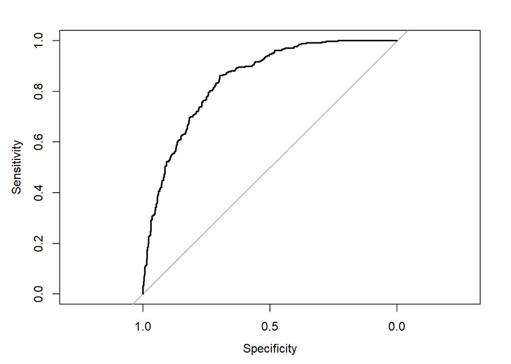

```r
rocModel4<-roc(testset4$Churn~predict4)
plot(rocModel4)
```

```r
rocModel4
```

```
##
## Call:
## roc.formula(formula = testset4$Churn ~ predict4)
##
## Data: predict4 in 645 controls (testset4$Churn No) < 333 cases (testset4$Churn Yes).
## Area under the curve: 0.8456
```

Modelimizin ROC değeri 0.8456 olarak görülüyor. 0.8’in üzerindeki değerler, modelin hedef değişkeni oluşturan iki kategoriyi ayırt etmede iyi bir iş çıkardığını gösterir. Diğer modellerle neredeyse aynı değere sahip.

## Dördüncü Model için Değerlendirme Metricleri

```r
predictClass4<-ifelse(predict4>0.5,"Yes","No")
predictClass4<-as.factor(predictClass4)
caret::confusionMatrix(predictClass4, reference=testset4$Churn)
```

```
## Confusion Matrix and Statistics
##
##           Reference
## Prediction  No Yes
##        No  537 122
##        Yes 108 211
##
##                Accuracy : 0.7648
##                  95% CI : (0.737, 0.7911)
##     No Information Rate : 0.6595
##     P-Value [Acc > NIR] : 5.04e-13
##
##                   Kappa : 0.471
##
##  Mcnemar's Test P-Value : 0.3913
##
##             Sensitivity : 0.8326
##             Specificity : 0.6336
##          Pos Pred Value : 0.8149
##          Neg Pred Value : 0.6614
##              Prevalence : 0.6595
##          Detection Rate : 0.5491
##    Detection Prevalence : 0.6738
##       Balanced Accuracy : 0.7331
##
##        'Positive' Class : No
##
```

```r
predictClass4<-ifelse(predict4>optCutoff4, "Yes", "No")
predictClass4<-as.factor(predictClass4)
caret::confusionMatrix(predictClass4, reference=testset4$Churn)
```

```
## Confusion Matrix and Statistics
##
##           Reference
## Prediction  No Yes
##        No    6   0
##        Yes 639 333
##
##                Accuracy : 0.3466
##                  95% CI : (0.3168, 0.3774)
##     No Information Rate : 0.6595
##     P-Value [Acc > NIR] : 1
##
##                   Kappa : 0.0064
##
##  Mcnemar's Test P-Value : <2e-16
##
##             Sensitivity : 0.009302
##             Specificity : 1.000000
##          Pos Pred Value : 1.000000
##          Neg Pred Value : 0.342593
##              Prevalence : 0.659509
##          Detection Rate : 0.006135
##    Detection Prevalence : 0.006135
##       Balanced Accuracy : 0.504651
##
##        'Positive' Class : No
##
```

İlk oluşturulan confusion matris sonuçlarından Accuracy değerine bakıldığında 0.7648 olarak görülüyor. Biz accuracy değerinin 0.8’den yukarıda olmasını bekliyoruz. İlk modelimiz’e göre biraz düşük Accuracy değeri elde edildi.

Kappa değeri 0.471 olarak elde edilmiş. Modelimiz ortalama iyi performansa sahiptir diyebiliriz. Kappa değerinin ilk modele göre biraz arttığı görülüyor ama bu artış kayda değer bir artış değil.

McNemar pvalue>0.05 False Positive ve False Negative birbirine benzerdir. İlk confusion matris sonucunda elde edilen McNemar değeri 0.3913 olduğu için False Positive ve False Negative birbirine benzerdir denebilir.

Sesitivity değeri 0.8326 olarak elde edilmiş. Elde edilen Sensitivity değerine göre modelimiz NoChurn gözlemlerini iyi bir şekilde tahmin edebiliyor. İlk modele kıyasla Sensitivity değerinde de düşüş var.

Pos Pred Value değeri 0.8149 olarak elde edilmiş. Bu değer de NoChurn tahmininin ne kadar iyi olduğunu gösteriyor. İlk modelle neredeyse aynı sonuç elde edildi.

Neg Pred Value değeri 0.6614 olarak elde edilmiş. Bu değer de YesChurn tahmininin kötü olduğunu gösteriyor. İlk modelle neredeyse aynı sonuç elde edildi.

CutOffOptimal’e göre oluşturulan ikinci confusion matris sonucunda accuracy değeri 0.3466 olarak elde edilmiş. Modelin doğru tahminlerinin çok düştüğü görülüyor.

Kappa değeri de 0.0064’lere gerilemiş. Kappa değerinin çok düşük olduğu söylenebilir.

Sensitivity değerinin de 0.009302’lere gerilediği görülüyor. Modelimizin CutOffOptimal’e göre oluşturulan confusion matris sonucuna göre NoChurn gözlemlerini çok kötü tahmin ettiği söylenebilir.

Specificity değerinin 1.000000’e yükseldiği görülüyor. Modelimizin YesChurn gözlemlerinin tamamını doğru tahmin ettiği görülüyor.

Özetle; modelimiz NoChurn gözlemlerini tahmin etmede ilk modelimize kıyasla daha kötü bir performansa sahip. YesChurn gözlemlerini tahmin etmedeki performansı daha iyi. İlk oluşturduğumuz modelin performansının daha iyi olduğu görülüyor.

## Precision Recall ve F1 Metriclerinin Olduğu Confusion Matris Üzerinden Dördüncü Modelin Değerlendirilmesi

```r
predictClass4<-ifelse(predict4>0.5, "Yes","No")
predictClass4<-as.factor(predictClass4)
caret::confusionMatrix(predictClass4, reference=testset4$Churn,positive="Yes",mode="prec_recall")
```

```
## Confusion Matrix and Statistics
##
##           Reference
## Prediction  No Yes
##        No  537 122
##        Yes 108 211
##
##                Accuracy : 0.7648
##                  95% CI : (0.737, 0.7911)
##     No Information Rate : 0.6595
##     P-Value [Acc > NIR] : 5.04e-13
##
##                   Kappa : 0.471
##
##  Mcnemar's Test P-Value : 0.3913
##
##               Precision : 0.6614
##                  Recall : 0.6336
##                      F1 : 0.6472
##              Prevalence : 0.3405
##          Detection Rate : 0.2157
##    Detection Prevalence : 0.3262
##       Balanced Accuracy : 0.7331
##
##        'Positive' Class : Yes
##
```

Oluşturulan confusion matris sonuçlarına bakıldığında Accuracy 0.7648 olarak hesaplanmış. 0.8’den düşük bir değer olduğu için yeterli seviyede değil diyebiliriz.

Kappa değeri 0.471 olarak hesaplanmış. Modelin performansı ortalama iyi seviyede denebilir.

Precision değeri 0.6614 olarak hesaplanmış. Modelin YesChurn gözlemlerini iyi tahmin edemediği söylenebilir.

Recall değeri 0.6336 olarak hesaplanmış. Modelin YesChurn gözlemlerini iyi tahmin edemediği söylenebilir.

F1 değeri de 0.6472 olarak hesaplanmış. Modelimizin Pozitive class olan YesChurn’ü iyi tahmin edemediğini gösteriyor.

## R2 McFadden

```r
pR2(model)["McFadden"];pR2(model2)["McFadden"];pR2(model3)["McFadden"];pR2(model4)["McFadden"]
```

```
## fitting null model for pseudo-r2
```

```
##  McFadden
## 0.2711008
```

```
## fitting null model for pseudo-r2
```

```
##  McFadden
## 0.2715498
```

```
## fitting null model for pseudo-r2
```

```
##  McFadden
## 0.2701086
```

```
## fitting null model for pseudo-r2
```

```
##  McFadden
## 0.2293564
```

Lojistic regresyonda uyumu değerlendirmede pseudo R2 kullanilir. 0’a cok yaklastiginda kötü, 0.4-0.5 arasinda ideal değer diyoruz.

Model1, model2, model3’ün R2 değerleri birbirine çok yakın. Model4’ün R2 değerinin çok düşük olduğu görülüyor.

Confusion matrisler üzerinden baktığımız diğer metriclerde de ilk modelimizin daha iyi değerleri olduğu için ilk modeli nihai model olarak seçip aykırı değer kontrolünü ve otokorelasyon kontrolünü ilk model üzerinden yapacağım.

## Aykırı Değer Kontrolü Mahalanobis Distance

Aykırı değerleri tespit etmek için öncelikle sayısal değişkenleri seçiyorum.

```r
numeric<-veriseti_imp%>%dplyr::select(-c(PhoneService,Contract,PaperlessBilling,PaymentMethod,Churn))
numeric.centre<-colMeans(numeric)
numeric.centre
```

```
##         tenure MonthlyCharges   TotalCharges
##       32.36637       64.75589     2279.45765
```

```r
numeric.cov<-cov(numeric)
numeric.cov
```

```
##                    tenure MonthlyCharges TotalCharges
## tenure           603.0931       183.0277     45967.12
## MonthlyCharges   183.0277       905.3020     44393.54
## TotalCharges   45967.1214     44393.5401   5134614.40
```

```r
distance<-mahalanobis(numeric, center = numeric.centre, cov=numeric.cov)
cutoff<-qchisq(p=0.95,df=3)
index<-which(distance>cutoff)
veriseti_imp5<-veriseti_imp[-index,]
```

cutoff değerinin 7.814728 olmasından, 7.814728 değerinin üzerindeki değerlerin aykırı değer olduğunu anlıyoruz. Aykırı değerlerin indexlerini belirleyip bu indeksteki gözlemleri verisetinden çıkartıyorum.

## Aykırı Gözlemlerden Arındırılmış Veriyi Eğitim ve Test Olarak Ayırma

```r
dataNoChurn5<-veriseti_imp5 %>% filter(Churn=="No")
dataYesChurn5<-veriseti_imp5 %>% filter(Churn=="Yes")

set.seed(155)
dataNoChurnIndex5<-sample(1:nrow(dataNoChurn5),size=0.75*nrow(dataNoChurn5))
set.seed(155)
dataYesChurnIndex5<-sample(1:nrow(dataYesChurn5),size=0.75*nrow(dataYesChurn5))
trainNoChurn5<-dataNoChurn5[dataNoChurnIndex5,]
trainYesChurn5<-dataYesChurn5[dataYesChurnIndex5,]

trainset5<-rbind(trainNoChurn5, trainYesChurn5)

testNoChurn5<-dataNoChurn5[-dataNoChurnIndex5,]
testYesChurn5<-dataYesChurn5[-dataYesChurnIndex5,]

testset5<-rbind(testNoChurn5, testYesChurn5)
```

Daha önce olduğu gibi bu adımda da %75 eğitim verisi %25 test verisi olarak ayırdım.

## Beşinci Modeli Kurma

```r
model5<-glm(Churn~., family = "binomial", data=trainset5)
summary(model5)
```

```
##
## Call:
## glm(formula = Churn ~ ., family = "binomial", data = trainset5)
##
## Deviance Residuals:
##     Min       1Q   Median       3Q      Max
## -1.7731  -0.7257  -0.3143   0.8355   3.6007
##
## Coefficients:
##                                        Estimate Std. Error z value Pr(>|z|)
## (Intercept)                          -7.671e-01  2.076e-01  -3.695 0.000220 ***
## tenure                               -6.365e-02  7.328e-03  -8.686  < 2e-16 ***
## PhoneServiceYes                      -9.077e-01  1.424e-01  -6.374 1.84e-10 ***
## ContractOne year                     -9.779e-01  1.208e-01  -8.092 5.86e-16 ***
## ContractTwo year                     -1.682e+00  1.900e-01  -8.852  < 2e-16 ***
## PaperlessBillingYes                   3.838e-01  8.390e-02   4.574 4.78e-06 ***
## PaymentMethodCredit card (automatic) -6.593e-02  1.302e-01  -0.506 0.612601
## PaymentMethodElectronic check         4.038e-01  1.070e-01   3.774 0.000161 ***
## PaymentMethodMailed check            -1.726e-01  1.307e-01  -1.320 0.186866
## MonthlyCharges                        2.276e-02  2.393e-03   9.512  < 2e-16 ***
## TotalCharges                          3.304e-04  8.247e-05   4.007 6.15e-05 ***
## ---
## Signif. codes:  0 '***' 0.001 '**' 0.01 '*' 0.05 '.' 0.1 ' ' 1
##
## (Dispersion parameter for binomial family taken to be 1)
##
##     Null deviance: 5919.6  on 5013  degrees of freedom
## Residual deviance: 4434.8  on 5003  degrees of freedom
## AIC: 4456.8
##
## Number of Fisher Scoring iterations: 6
```

```r
anova(model5)
```

```
## Analysis of Deviance Table
##
## Model: binomial, link: logit
##
## Response: Churn
##
## Terms added sequentially (first to last)
##
##
##                  Df Deviance Resid. Df Resid. Dev
## NULL                              5013     5919.6
## tenure            1   582.22      5012     5337.4
## PhoneService      1     0.76      5011     5336.7
## Contract          2   374.09      5009     4962.6
## PaperlessBilling  1   125.67      5008     4836.9
## PaymentMethod     3   143.94      5005     4693.0
## MonthlyCharges    1   241.67      5004     4451.3
## TotalCharges      1    16.52      5003     4434.8
```

```r
varImp(model5)
```

```
##                                        Overall
## tenure                               8.6864737
## PhoneServiceYes                      6.3743762
## ContractOne year                     8.0922936
## ContractTwo year                     8.8515111
## PaperlessBillingYes                  4.5742600
## PaymentMethodCredit card (automatic) 0.5063636
## PaymentMethodElectronic check        3.7735153
## PaymentMethodMailed check            1.3199064
## MonthlyCharges                       9.5116578
## TotalCharges                         4.0070241
```

```r
exp(coef(model5))
```

```
##                          (Intercept)                               tenure
##                            0.4643503                            0.9383330
##                      PhoneServiceYes                     ContractOne year
##                            0.4034645                            0.3761043
##                     ContractTwo year                  PaperlessBillingYes
##                            0.1859682                            1.4678261
## PaymentMethodCredit card (automatic)        PaymentMethodElectronic check
##                            0.9361946                            1.4975329
##            PaymentMethodMailed check                       MonthlyCharges
##                            0.8415004                            1.0230218
##                         TotalCharges
##                            1.0003305
```

Modelin sonuçlarından, PaymentMethodCredit card (automatic) ve PaymentMethodMailed check değişkeninin anlamsız olduğu diğer değişkenlerin anlamlı olduğu görülüyor.

Anova ve varImp sonuçlarından da değişkenlerin modele olumlu katkılarının olduğu görülüyor.

Exp(coef(model)) sonuçlarına baktığımızda ise odds oranlarını görüyoruz.

Diğer değişkenlerin odds oranından benzer yorumlar yapılabilir. En son adımda tüm kontrolleri yapıp tüm değişkenlerin etkilerini detaylıca yorumlayacağım.

## Beşinci Model Üzerinden Predictlerin Hesaplanması ve Confusion Matrislerin Oluşturulması

```r
predict5<-predict(model5, testset5, type="response")
summary(predict5)
```

```
##     Min.  1st Qu.   Median     Mean  3rd Qu.     Max.
## 0.001572 0.061818 0.225577 0.281790 0.489876 0.790608
```

```r
cm5<-InformationValue::confusionMatrix(testset5$Churn,predictedScores=predict5)
cm5
```

```
##     No Yes
## 0 1055 215
## 1  154 249
```

```r
optCutoff5<-InformationValue::optimalCutoff(testset5$Churn, predictedScores=predict5)
optCutoff5
```

```
## [1] 0.01060826
```

```r
cmOpt5<-InformationValue::confusionMatrix(testset5$Churn, predictedScores = predict5>optCutoff5)
cmOpt5
```

```
##     No Yes
## 0   95   2
## 1 1114 462
```

Predict sonuçlarından median değerinin 0.2256 olmasından çoğu değerin 0’a yakın olduğunu anlıyoruz.

İlk oluşturulan confusion matris sonuçları incelendiğinde, modelimizin toplamda 1209 NoChurn gözleminin 1055’ini NoChurn olaran tahmin ettiği, 464 YesChurn gözleminin ise sadece 249’unu YesChurn olarak tahmin ettiği görülüyor. NoChurn’ü tahmin etmede daha başarılı olduğu görülüyor.

## ROC Eğrisi

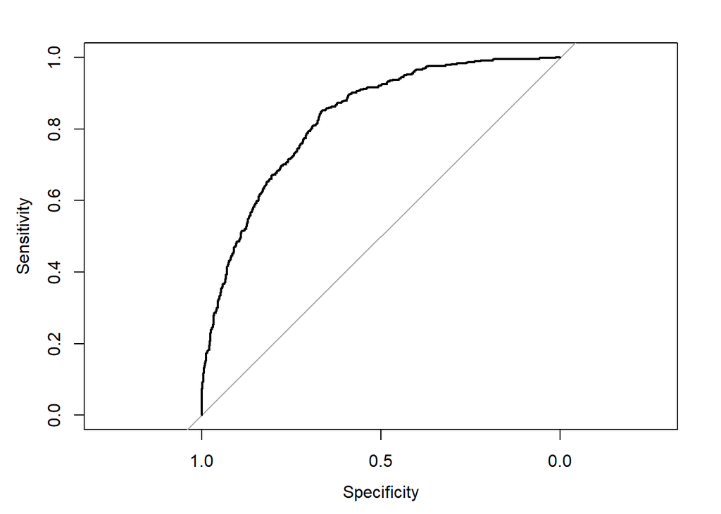

```r
rocModel<-roc(testset5$Churn~predict5)
plot(rocModel)
```

```r
rocModel
```

```
##
## Call:
## roc.formula(formula = testset5$Churn ~ predict5)
##
## Data: predict5 in 1209 controls (testset5$Churn No) < 464 cases (testset5$Churn Yes).
## Area under the curve: 0.8277
```

Modelimizin ROC değeri 0.8277 olarak görülüyor. 0.8’in üzerindeki değerler, modelin hedef değişkeni oluşturan iki kategoriyi ayırt etmede iyi bir iş çıkardığını gösterir. Diğer modellerle neredeyse aynı değere sahip.

## Beşinci Model için Değerlendirme Metricleri

```r
predictClass5<-ifelse(predict5>0.5,"Yes","No")
predictClass5<-as.factor(predictClass5)
caret::confusionMatrix(predictClass5, reference=testset5$Churn)
```

```
## Confusion Matrix and Statistics
##
##           Reference
## Prediction   No  Yes
##        No  1055  215
##        Yes  154  249
##
##                Accuracy : 0.7794
##                  95% CI : (0.7588, 0.7991)
##     No Information Rate : 0.7227
##     P-Value [Acc > NIR] : 6.524e-08
##
##                   Kappa : 0.4265
##
##  Mcnemar's Test P-Value : 0.001787
##
##             Sensitivity : 0.8726
##             Specificity : 0.5366
##          Pos Pred Value : 0.8307
##          Neg Pred Value : 0.6179
##              Prevalence : 0.7227
##          Detection Rate : 0.6306
##    Detection Prevalence : 0.7591
##       Balanced Accuracy : 0.7046
##
##        'Positive' Class : No
##
```

```r
predictClass5<-ifelse(predict5>optCutoff5, "Yes", "No")
predictClass5<-as.factor(predictClass5)
caret::confusionMatrix(predictClass5, reference=testset5$Churn)
```

```
## Confusion Matrix and Statistics
##
##           Reference
## Prediction   No  Yes
##        No    95    2
##        Yes 1114  462
##
##                Accuracy : 0.3329
##                  95% CI : (0.3104, 0.3561)
##     No Information Rate : 0.7227
##     P-Value [Acc > NIR] : 1
##
##                   Kappa : 0.0427
##
##  Mcnemar's Test P-Value : <2e-16
##
##             Sensitivity : 0.07858
##             Specificity : 0.99569
##          Pos Pred Value : 0.97938
##          Neg Pred Value : 0.29315
##              Prevalence : 0.72265
##          Detection Rate : 0.05678
##    Detection Prevalence : 0.05798
##       Balanced Accuracy : 0.53713
##
##        'Positive' Class : No
##
```

İlk oluşturulan confusion matris sonuçlarından Accuracy değerine bakıldığında 0.7794 olarak görülüyor. Biz accuracy değerinin 0.8’den yukarıda olmasını bekliyoruz. İlk modelimiz’e göre biraz düşük Accuracy değeri elde edildi.

Kappa değeri 0.4265 olarak elde edilmiş. Modelimiz ortalama iyi performansa sahiptir diyebiliriz. Kappa değerinin de ilk modele göre düştüğü görülüyor.

McNemar pvalue>0.05 False Positive ve False Negative birbirine benzerdir. İlk confusion matris sonucunda elde edilen McNemar değeri 0.001787 olduğu için False Positive ve False Negative birbirine benzer değildir denebilir.

Sesitivity değeri 0.8726 olarak elde edilmiş. Elde edilen Sensitivity değerine göre modelimiz NoChurn gözlemlerini iyi bir şekilde tahmin edebiliyor. İlk modele kıyasla Sensitivity değerinde de düşüş var.

Specificity değeri 0.5366 olarak elde edilmiş. Elde edilen Specificity değerine göre modelimiz YesChurn gözlemlerini kötü bir şekilde tahmin edebiliyor. İlk modele kıyasla neredeyse eşit Specificity değerine sahip.

Pos Pred Value değeri 0.8307 olarak elde edilmiş. Bu değer de NoChurn tahmininin ne kadar iyi olduğunu gösteriyor. İlk modelle neredeyse aynı sonuç elde edildi.

Neg Pred Value değeri 0.6179 olarak elde edilmiş. Bu değer de YesChurn tahmininin kötü olduğunu gösteriyor. İlk modelle neredeyse aynı sonuç elde edildi.

Optimal cutoff’a göre oluşturulan ikinci confusion matris sonucunda accuracy değeri 0.3329 olarak elde edilmiş. Modelin doğru tahminlerinin çok düştüğü görülüyor.

Kappa değeri de 0.0427’lere gerilemiş. Kappa değerinin çok düşük olduğu söylenebilir.

Sensitivity değerinin de 0.07858’lere gerilediği görülüyor. Modelimizin Optimal cutoff’a göre oluşturulan confusion matris sonucuna göre NoChurn gözlemlerini çok kötü tahmin ettiği söylenebilir.

Specificity değerinin 0.99569’a yükseldiği görülüyor. Modelimizin YesChurn gözlemlerinin neredeyse tamamını doğru tahmin ettiği görülüyor.

Özetle; modelimiz NoChurn gözlemlerini tahmin etmede ilk modelimize kıyasla daha kötü bir performansa sahip. YesChurn gözlemlerini tahmin etmedeki performansı daha iyi. İlk oluşturduğumuz modelin performansının daha iyi olduğu görülüyor.

## Precision Recall ve F1 Metriclerinin Olduğu Confusion Matris Üzerinden Beşinci Modelin Değerlendirilmesi

```r
predictClass5<-ifelse(predict5>0.5, "Yes","No")
predictClass5<-as.factor(predictClass5)
caret::confusionMatrix(predictClass5, reference=testset5$Churn,positive="Yes",mode="prec_recall")
```

```
## Confusion Matrix and Statistics
##
##           Reference
## Prediction   No  Yes
##        No  1055  215
##        Yes  154  249
##
##                Accuracy : 0.7794
##                  95% CI : (0.7588, 0.7991)
##     No Information Rate : 0.7227
##     P-Value [Acc > NIR] : 6.524e-08
##
##                   Kappa : 0.4265
##
##  Mcnemar's Test P-Value : 0.001787
##
##               Precision : 0.6179
##                  Recall : 0.5366
##                      F1 : 0.5744
##              Prevalence : 0.2773
##          Detection Rate : 0.1488
##    Detection Prevalence : 0.2409
##       Balanced Accuracy : 0.7046
##
##        'Positive' Class : Yes
##
```

İlk modele kıyasla Accuracy değerinin, Kappa değerinin ve diğer metriclerin düştüğü görülüyor.

## R2 McFadden

```r
pR2(model)["McFadden"];pR2(model5)["McFadden"]
```

```
## fitting null model for pseudo-r2
```

```
##  McFadden
## 0.2711008
```

```
## fitting null model for pseudo-r2
```

```
## McFadden
## 0.250838
```

## Otokorelasyon (DW Test)

```r
dwtest(model5)
```

```
##
##  Durbin-Watson test
##
## data:  model5
## DW = 0.50699, p-value < 2.2e-16
## alternative hypothesis: true autocorrelation is greater than 0
```

Durbin-Watson testte H0 hipotezi, hatalar arasinda korelasyon yoktur seklinde kurulur. Durbin Watson test sonucundan pvalue degerlendirildiginde H0 hipotezi reddedilir yani hatalar arasinda korelasyon olduğu görülür. Ayrıca hesaplanan DW degeri 0 ile 4 arasinda deger almaktadir. 2 degerine yakin elde edilen DW degeri otokorelasyon olmadığına isaret eder. 0’a yakın değer alması pozitif korelasyona, 4’e yakin deger almasi da negatif korelasyona işaret etmektedir.

## Nihai Modelin Detaylı Açıklanması

```r
summary(model)
```

```
##
## Call:
## glm(formula = Churn ~ ., family = "binomial", data = trainset)
##
## Deviance Residuals:
##     Min       1Q   Median       3Q      Max
## -1.8224  -0.7039  -0.2744   0.7939   3.2756
##
## Coefficients:
##                                        Estimate Std. Error z value Pr(>|z|)
## (Intercept)                          -8.891e-01  2.054e-01  -4.328 1.50e-05 ***
## tenure                               -6.695e-02  7.293e-03  -9.180  < 2e-16 ***
## PhoneServiceYes                      -7.979e-01  1.426e-01  -5.597 2.18e-08 ***
## ContractOne year                     -9.494e-01  1.219e-01  -7.787 6.87e-15 ***
## ContractTwo year                     -2.017e+00  2.083e-01  -9.683  < 2e-16 ***
## PaperlessBillingYes                   4.403e-01  8.408e-02   5.237 1.63e-07 ***
## PaymentMethodCredit card (automatic)  1.795e-02  1.297e-01   0.138    0.890
## PaymentMethodElectronic check         4.924e-01  1.072e-01   4.595 4.32e-06 ***
## PaymentMethodMailed check            -8.503e-02  1.305e-01  -0.652    0.515
## MonthlyCharges                        2.117e-02  2.346e-03   9.025  < 2e-16 ***
## TotalCharges                          3.762e-04  8.108e-05   4.640 3.49e-06 ***
## ---
## Signif. codes:  0 '***' 0.001 '**' 0.01 '*' 0.05 '.' 0.1 ' ' 1
##
## (Dispersion parameter for binomial family taken to be 1)
##
##     Null deviance: 6109.7  on 5279  degrees of freedom
## Residual deviance: 4453.4  on 5269  degrees of freedom
## AIC: 4475.4
##
## Number of Fisher Scoring iterations: 6
```

```r
anova(model)
```

```
## Analysis of Deviance Table
##
## Model: binomial, link: logit
##
## Response: Churn
##
## Terms added sequentially (first to last)
##
##
##                  Df Deviance Resid. Df Resid. Dev
## NULL                              5279     6109.7
## tenure            1   712.21      5278     5397.5
## PhoneService      1     2.44      5277     5395.0
## Contract          2   406.22      5275     4988.8
## PaperlessBilling  1   132.95      5274     4855.9
## PaymentMethod     3   141.10      5271     4714.8
## MonthlyCharges    1   238.98      5270     4475.8
## TotalCharges      1    22.43      5269     4453.4
```

```r
varImp(model)
```

```
##                                        Overall
## tenure                               9.1800957
## PhoneServiceYes                      5.5970875
## ContractOne year                     7.7869193
## ContractTwo year                     9.6833229
## PaperlessBillingYes                  5.2368432
## PaymentMethodCredit card (automatic) 0.1383832
## PaymentMethodElectronic check        4.5953013
## PaymentMethodMailed check            0.6516443
## MonthlyCharges                       9.0251229
## TotalCharges                         4.6395482
```

```r
exp(coef(model))
```

```
##                          (Intercept)                               tenure
##                            0.4110165                            0.9352444
##                      PhoneServiceYes                     ContractOne year
##                            0.4502576                            0.3869539
##                     ContractTwo year                  PaperlessBillingYes
##                            0.1331024                            1.5531816
## PaymentMethodCredit card (automatic)        PaymentMethodElectronic check
##                            1.0181135                            1.6362799
##            PaymentMethodMailed check                       MonthlyCharges
##                            0.9184885                            1.0213942
##                         TotalCharges
##                            1.0003763
```

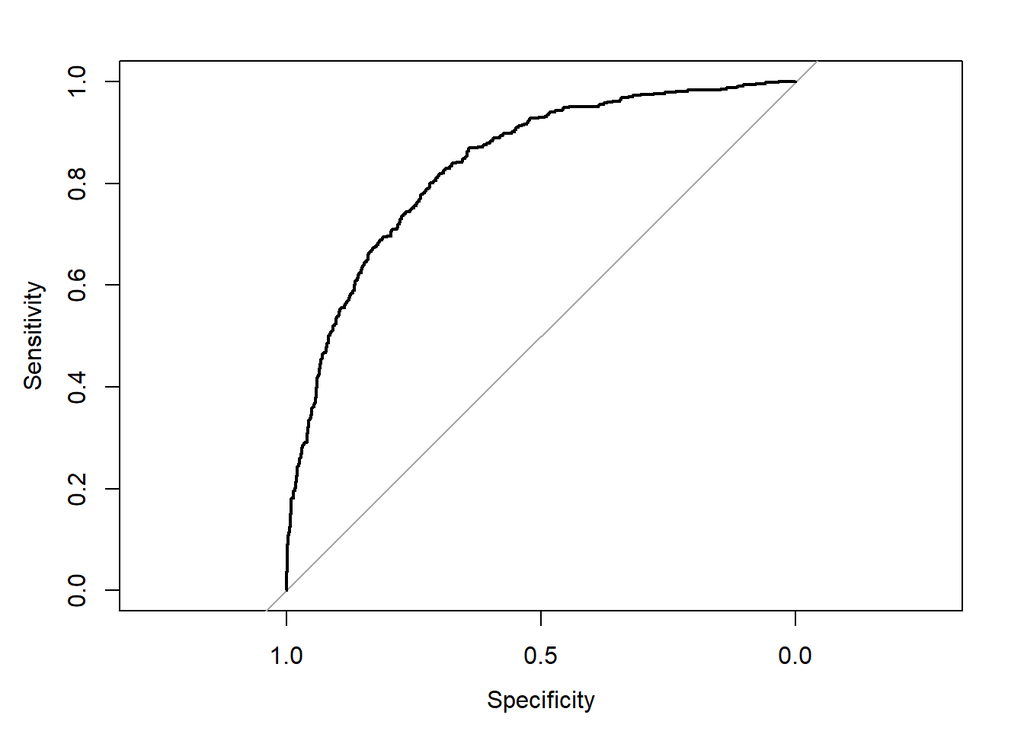

```r
rocModel<-roc(testset$Churn~predict1)
plot(rocModel)
```

```r
rocModel
```

```
##
## Call:
## roc.formula(formula = testset$Churn ~ predict1)
##
## Data: predict1 in 1294 controls (testset$Churn No) < 468 cases (testset$Churn Yes).
## Area under the curve: 0.8361
```

İlk modelimi, verisetimdeki missing değerleri doldurup kurdum. Diğer modelleri kurarken; anlamsız değişkenleri, vif değeri yüksek olan değişkeni, aykırı gözlemleri modelden çıkarttım. Buna rağmen model performansları düştü. Bu yüzden aykırı gözlemlerin ve anlamsız gözüken değişkenlerin modelde kalmasına karar verdim. Model performansı ve metric değerlendirmeleri sonucunda ilk modelimin nihai model olmasına karar verdim.

Nihai modelimizin sonuçlarına bakıldığında PaymentMethodCredit card (automatic) değişkeni ve PaymentMethodMailed check değişkeninin anlamsız çıktığı, diğer değişkenlerin anlamlı çıktığı p değerlerinden anlaşılıyor. Ödevimin başlarında da bu durumu fark edip anlamsız çıkan değişkenlerin gözlemlerini verisetimden çıkartıp model kurduğumda modelin performansının düştüğünü gördüm. Zaten bu değişkenler Dummy değişken olarak tanımlanmış. Modelin performansının daha iyi olması için bu değişkenlerin modelde kalmasına karar verdim.

Nihai modeldeki değişkenlerin katsayılarına bakıldığında, X’ler sırasıyla tenure değişkeninden başlayıp TotalCharges değişkenine kadar giden bağımsız değişkenleri temsil etmek üzere denklem yaklaşık olarak şu şekilde kurulmuş:

-0.8893 - 0.066X1 - 0.79X2 - 0.94X3 - 2.01X4 + 0.44X5 + 0.01X6+0.49X7 - 0.08X8 + 0.02X9 + 0.00X10

Anova ve varImp sonuçlarına baktığımda öncelikle değişkensiz kurulan modelin Residual Deviance’ının 6109 olduğunu gördüm. Biz Residual Deviance’nin düşük olmasını istiyoruz. Sonrasında, modele eklenen her değişkenin Residual Deviance değerini düşürdüğü görülüyor. Anova sonuçlarından bağımsız değişkenlerin modele olan katkısını inceledim.

Exp(coef(model)) sonuçlarına baktığımızda ise odds oranlarını görüyoruz. Bir değişkenin odds oranı 1’e yakınsa etki yok, 1’den yüksekse arttirici etkiye sahip, 1’den azsa azaltıcı etkiye sahip olduğunu anlıyoruz.

Modelimizin ROC değeri 0.8361 olarak görülüyor. 0.8’in üzerindeki değerler, modelin hedef değişkeni oluşturan iki kategoriyi ayırt etmede iyi bir iş çıkardığını gösterir. Yani modelimizin NoChurn ve YesChurn’ü bulmada iyi iş çıkardığını söyleyebiliriz.

## Metricler

```r
predictClass<-ifelse(predict1>0.5,"Yes","No")
predictClass<-as.factor(predictClass)
caret::confusionMatrix(predictClass, reference=testset$Churn)
```

```
## Confusion Matrix and Statistics
##
##           Reference
## Prediction   No  Yes
##        No  1168  219
##        Yes  126  249
##
##                Accuracy : 0.8042
##                  95% CI : (0.7849, 0.8225)
##     No Information Rate : 0.7344
##     P-Value [Acc > NIR] : 4.624e-12
##
##                   Kappa : 0.4641
##
##  Mcnemar's Test P-Value : 7.304e-07
##
##             Sensitivity : 0.9026
##             Specificity : 0.5321
##          Pos Pred Value : 0.8421
##          Neg Pred Value : 0.6640
##              Prevalence : 0.7344
##          Detection Rate : 0.6629
##    Detection Prevalence : 0.7872
##       Balanced Accuracy : 0.7173
##
##        'Positive' Class : No
##
```

```r
predictClass1<-ifelse(predict1>optCutoff, "Yes", "No")
predictClass1<-as.factor(predictClass1)
caret::confusionMatrix(predictClass1, reference=testset$Churn)
```

```
## Confusion Matrix and Statistics
##
##           Reference
## Prediction   No  Yes
##        No   123    3
##        Yes 1171  465
##
##                Accuracy : 0.3337
##                  95% CI : (0.3117, 0.3563)
##     No Information Rate : 0.7344
##     P-Value [Acc > NIR] : 1
##
##                   Kappa : 0.0493
##
##  Mcnemar's Test P-Value : <2e-16
##
##             Sensitivity : 0.09505
##             Specificity : 0.99359
##          Pos Pred Value : 0.97619
##          Neg Pred Value : 0.28423
##              Prevalence : 0.73439
##          Detection Rate : 0.06981
##    Detection Prevalence : 0.07151
##       Balanced Accuracy : 0.54432
##
##        'Positive' Class : No
##
```

```r
predictClass<-ifelse(predict1>0.5, "Yes","No")
predictClass<-as.factor(predictClass)
caret::confusionMatrix(predictClass, reference=testset$Churn,positive="Yes",mode="prec_recall")
```

```
## Confusion Matrix and Statistics
##
##           Reference
## Prediction   No  Yes
##        No  1168  219
##        Yes  126  249
##
##                Accuracy : 0.8042
##                  95% CI : (0.7849, 0.8225)
##     No Information Rate : 0.7344
##     P-Value [Acc > NIR] : 4.624e-12
##
##                   Kappa : 0.4641
##
##  Mcnemar's Test P-Value : 7.304e-07
##
##               Precision : 0.6640
##                  Recall : 0.5321
##                      F1 : 0.5907
##              Prevalence : 0.2656
##          Detection Rate : 0.1413
##    Detection Prevalence : 0.2128
##       Balanced Accuracy : 0.7173
##
##        'Positive' Class : Yes
##
```

```r
pR2(model)["McFadden"]
```

```
## fitting null model for pseudo-r2
```

```
##  McFadden
## 0.2711008
```

Metricleri caret paketi üzerinden incelerken, confusion matris’i oluştururken mode’u belirtmezsek metriclerimizi accuracy bazlı olarak hesaplar. İlk iki confusion matrislerin sonucunda oluşan metricler Accuracy bazlı olarak hesaplanan metriclerdir.

İlk oluşturulan confusion matris sonucu incelenirse, öncelikle Pozitive Class’ımız NoChurn sınıfı olduğunu en alt satırdan anlıyoruz. Yani Sensitivity değerimiz ve Pos Pred Value değerimiz, modelimizin NoChurn sınıfını yani kişinin telekom firmasını kullanmaya devam etmesi durumunu ne kadar iyi tahmin ettiğini gösteriyor.

İlk oluşturulan confusion matris sonuçlarından Accuracy değerine bakıldığında 0.8042 olarak görülüyor. Bu değer, modelimizin NoChurn olarak tahmin ettikleri ile modelimizin YesChurn olarak tahmin ettiklerinin toplamının tüm değerlere oranını veriyor. Yani modelimizin doğru tahmin etme oranını veriyor. Biz accuracy değerinin 0.8’den yukarıda olmasını bekliyoruz. Elde edilen 0.8042 accuracy değeri kabul edilebilir denebilir.

Kappa değeri 0.4641 olarak elde edilmiş. Kappa değeri de modelin performansını gösteren bir değerdir. 0.4 civarında olması ortalama iyi performansı işaret eder. Modelimiz ortalama iyi performansa sahiptir diyebiliriz.

McNemar pvalue>0.05 False Positive ve False Negative birbirine benzerdir. Elde edilen McNemar değeri çok küçük bir değer olduğu için False Positive ve False Negative birbirine benzer değildir denebilir.

Sesitivity değeri 0.9026 olarak elde edilmiş. Sensitivity, modelin NoChurn olarak tahmin ettiklerinin gerçekte NoChurn olanlara oranını veriyor. Yani modelin NoChurn değerini ne kadar iyi tahmin ettiğini gösteriyor. 0.9026 olarak elde edilen Sensitivity değerine göre modelimiz NoChurn gözlemlerini çok iyi bir şekilde tahmin edebiliyor. Ben de NoChurn tahmini iyi olan bir model oluşturmak istediğim için bu model için sensitivity değeri gayet iyi diyebilirim.

Specificity değeri 0.5321 olarak elde edilmiş. Specificity, modelin YesChurn olarak tahmin ettiklerinin gerçekte YesChurn olanlara oranını veriyor. Yani modelin YesChurn değerini ne kadar iyi tahmin ettiğini gösteriyor. 0.5321 olarak elde edilen Specificity değerine göre modelimiz YesChurn gözlemlerini kötü bir şekilde tahmin edebiliyor.

Pos Pred Value değeri 0.8421 olarak elde edilmiş. Bu değer de NoChurn tahmininin ne kadar iyi olduğunu gösteriyor. Sensitivity sonucunu destekliyor.

Neg Pred Value değeri 0.6640 olarak elde edilmiş. Bu değer de YesChurn tahmininin kötü olduğunu gösteriyor. Specificity sonucunu destekliyor.

CutOffOptimal’e göre oluşturulan ikinci confusion matris sonucunda accuracy değeri 0.3337 olarak elde edilmiş. Modelin doğru tahminlerinin çok düştüğü görülüyor.

Kappa değeri de 0.0493’lere gerilemiş. Kabul edilemeyecek seviyelerde denebilir.

Sensitivity değerinin de 0.09’lara gerilediği görülüyor. Modelimizin CutOffOptimal’e göre olşturulan confusion matris sonucuna göre NoChurn gözlemlerini çok kötü tahmin ettiği söylenebilir.

Specificity değerinin 0.99359’a yükseldiği görülüyor. Modelimizin YesChurn gözlemlerinin neredeyse tamamını doğru tahmin ettiği söylenebilir. Ben NoChurn değerini iyi tahmin etmesini istediğim için ilk oluşturulan confusion matrisin sonuçları daha iyi diyebilirim.

Precision ve Recall bazlı olarak oluşturulan confusion matris sonuçlarına bakıldığında Accuracy 0.8042 olarak hesaplanmış. Modelin doğru tahminlerinin yeterli seviyede olduğu söylenebilir.

Kappa değeri 0.4641 olarak hesaplanmış. Modelin performansı ortalama iyi seviyede denebilir.

Precision değeri, modelin YesChurn olarak tahmin ettiği ve gerçekte de YesChurn olan gözlemlerin, modelin tüm YesChurn tahminlerine oranını veriyor. Yani modelimizin YesChurn gözlemlerini ne kadar iyi tahmin ettiğini gösteren bir metrictir. 0.6640 olarak hesaplanmış. Modelin YesChurn gözlemlerini çok da iyi tahmin edemediği söylenebilir.

Recall değeri, modelimizin YesChurn olarak tahmin ettiği ve gerçekte de YesChurn olan gözlemlerin, gerçekteki tüm YesChurn gözlemlerine oranını veriyor. Modelimizin YesChurn gözlemlerini ne kadar iyi tahmin ettiğini gösteren bir metrictir. 0.5321 olarak hesaplanmış. Modelin YesChurn gözlemlerini iyi tahmin edemediği söylenebilir.

F1 değeri de Precision ve Recall değerlerinin harmanlanmış hali denebilir. 0.5907 olarak hesaplanmış. Modelimizin Pozitive class olan YesChurn’ü iyi tahmin edemediğini gösteriyor.

Optimal cutoff’a göre hesaplanan metricleri ve Precision ve Recall bazlı hesaplanan metricleri dikkate almama gerek yok. Çünkü bu confusion matrislerde oluşturulan metricler modelin YesChurn gözlemlerini tahmin etmedeki başarısını gösteriyor. Dolayısıyla Accuracy bazlı oluşturulan ilk matrisin sonuçlarını dikkate almam yeterli.